# Data Analysis with R, Python and Rcpp

2023-09-27

- **Contributor:** P.BADY
- **Date:** Tue Jul 21 15:00:44 2026
- **Abstract:**

```
License: GPL version 2 or newer
Copyright (C) 2009-2017  Pierre Bady

This program is free software/document; you can redistribute it and/or
modify it under the terms of the GNU General Public License
as published by the Free Software Foundation; either version 2
of the License, or (at your option) any later version.

This program/document is distributed in the hope that it will be useful,
but WITHOUT ANY WARRANTY; without even the implied warranty of
MERCHANTABILITY or FITNESS FOR A PARTICULAR PURPOSE.  See the
GNU General Public License for more details.
```

# 1 Motivations

The objective of this document is to propose an implementation of data analysis methods based on duality diagram in python and to develop and expand my skill in python. The document contains information related to the use of Rcpp (R and C++).

# 2 first test PCA based on R package ade4

Back to top

## 2.1 Example from the R package ade4

```r
library(ade4)
data(deug)
pca1 <- dudi.pca(deug$tab, center = deug$cent, scale = FALSE, scan = FALSE)
pca2 <- dudi.pca(deug$tab, center = TRUE, scale = TRUE, scan = FALSE)
```

The script can be directly usd in Rstudio and R via the R package reticulate (https://rstudio.github.io/reticulate/).

```r
write.csv(deug$tab,file="data/deugtab.csv")
```

## 2.2 Data importation

see for example: https://www.kaggle.com/code/arnopub/pandas-pr-sentation-des-dataframe

```python
import numpy as np
import pandas as pd
deugtab = pd.read_csv('data/deugtab.csv')
deugtab
```

```
##      Unnamed: 0  Algebra  Analysis  Proba  ...  Option1  Option2  English  Sport
## 0             1       40      26.0     26  ...       17     24.0     19.0   11.5
## 1             2       37      34.5     37  ...       24     22.0     26.0   11.5
## 2             3       37      41.0     29  ...       24     27.0     19.6   11.5
## 3             4       63      37.5     57  ...       23     23.0     21.0   14.0
## 4             5       55      31.5     34  ...       19     24.0     24.0   11.5
## ..          ...      ...       ...    ...  ...      ...      ...      ...    ...
## 99          100       60      41.0     18  ...       20     24.0     17.2    0.0
## 100         101       48      44.0     22  ...       22     28.0     19.6    0.0
## 101         102       44      45.0     42  ...       27     22.0     18.4   15.0
## 102         103       47      32.0     26  ...       23     28.0     19.0   11.5
## 103         104       44      32.0     42  ...       28     27.5     23.0   11.5
##
## [104 rows x 10 columns]
```

```python
del deugtab['Unnamed: 0']
deugtab
```

```
##      Algebra  Analysis  Proba  Informatic  ...  Option1  Option2  English  Sport
## 0         40      26.0     26        26.0  ...       17     24.0     19.0   11.5
## 1         37      34.5     37        32.0  ...       24     22.0     26.0   11.5
## 2         37      41.0     29        34.5  ...       24     27.0     19.6   11.5
## 3         63      37.5     57        35.5  ...       23     23.0     21.0   14.0
## 4         55      31.5     34        36.0  ...       19     24.0     24.0   11.5
## ..       ...       ...    ...         ...  ...      ...      ...      ...    ...
## 99        60      41.0     18        30.0  ...       20     24.0     17.2    0.0
## 100       48      44.0     22        30.0  ...       22     28.0     19.6    0.0
## 101       44      45.0     42        35.0  ...       27     22.0     18.4   15.0
## 102       47      32.0     26        21.0  ...       23     28.0     19.0   11.5
## 103       44      32.0     42        26.5  ...       28     27.5     23.0   11.5
##
## [104 rows x 9 columns]
```

# 3 PCA from scratch in python

Back to top

PCA from scratch (https://towardsdatascience.com/principal-component-analysis-from-scratch-in-numpy-61843da1f967)

```python
# centering = TRUE
X= deugtab - deugtab.mean()
# Normalize
Z = X / X.std(ddof=0)
print('MEAN:')
```

```
## MEAN:
```

```python
print(Z.mean())
```

```
## Algebra      -9.394195e-17
## Analysis      3.928481e-16
## Proba        -1.003471e-16
## Informatic   -1.579933e-16
## Economy       4.782499e-16
## Option1      -1.281027e-17
## Option2       1.814788e-16
## English      -9.137990e-16
## Sport         1.665335e-16
## dtype: float64
```

```python
print('---'*15)
print('STD:')
```

```
## STD:
```

```python
print(Z.std(ddof=0))
```

```
## Algebra       1.0
## Analysis      1.0
## Proba         1.0
## Informatic    1.0
## Economy       1.0
## Option1       1.0
## Option2       1.0
## English       1.0
## Sport         1.0
## dtype: float64
```

diagonalisation and eigenvectors

```python
import numpy as np
len(Z)
```

```
## 104
```

```python
ZZ = np.dot(Z.T, Z)/len(Z)
eigenvalues, eigenvectors = np.linalg.eig(ZZ)
D = np.diag(eigenvalues)
P = eigenvectors
Z_new = np.dot(Z, P)
```

valeur propres non ordonnées !!!!

Calculate the proportion of variance explained by each feature

```python
sum_eigenvalues = np.sum(eigenvalues)
sum_eigenvalues
```

```
## 9.000000000000002
```

```python
prop_var = [i/sum_eigenvalues for i in eigenvalues]
```

Calculate the cumulative variance

```python
cum_var = [np.sum(prop_var[:i+1]) for i in range(len(prop_var))]
```

Plot scree plot from PCA

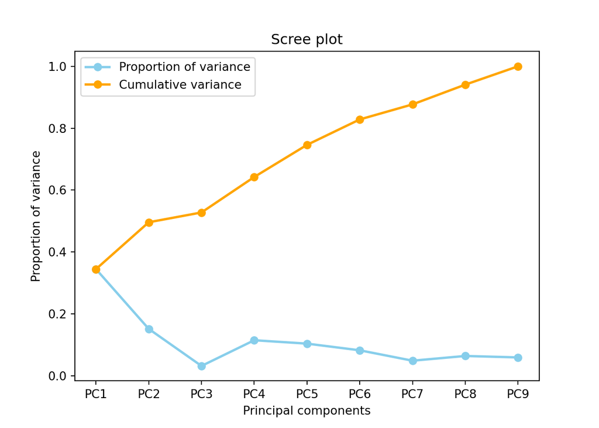

```python
import matplotlib.pyplot as plt
x_labels = ['PC{}'.format(i+1) for i in range(len(prop_var))]
plt.plot(x_labels, prop_var, marker='o', markersize=6, color='skyblue', linewidth=2, label='Proportion of variance')
plt.plot(x_labels, cum_var, marker='o', color='orange', linewidth=2, label="Cumulative variance")
plt.legend()
plt.title('Scree plot')
plt.xlabel('Principal components')
plt.ylabel('Proportion of variance')
plt.show()
```

# 4 Collaboration R and python

Back to top

https://rstudio.github.io/reticulate/

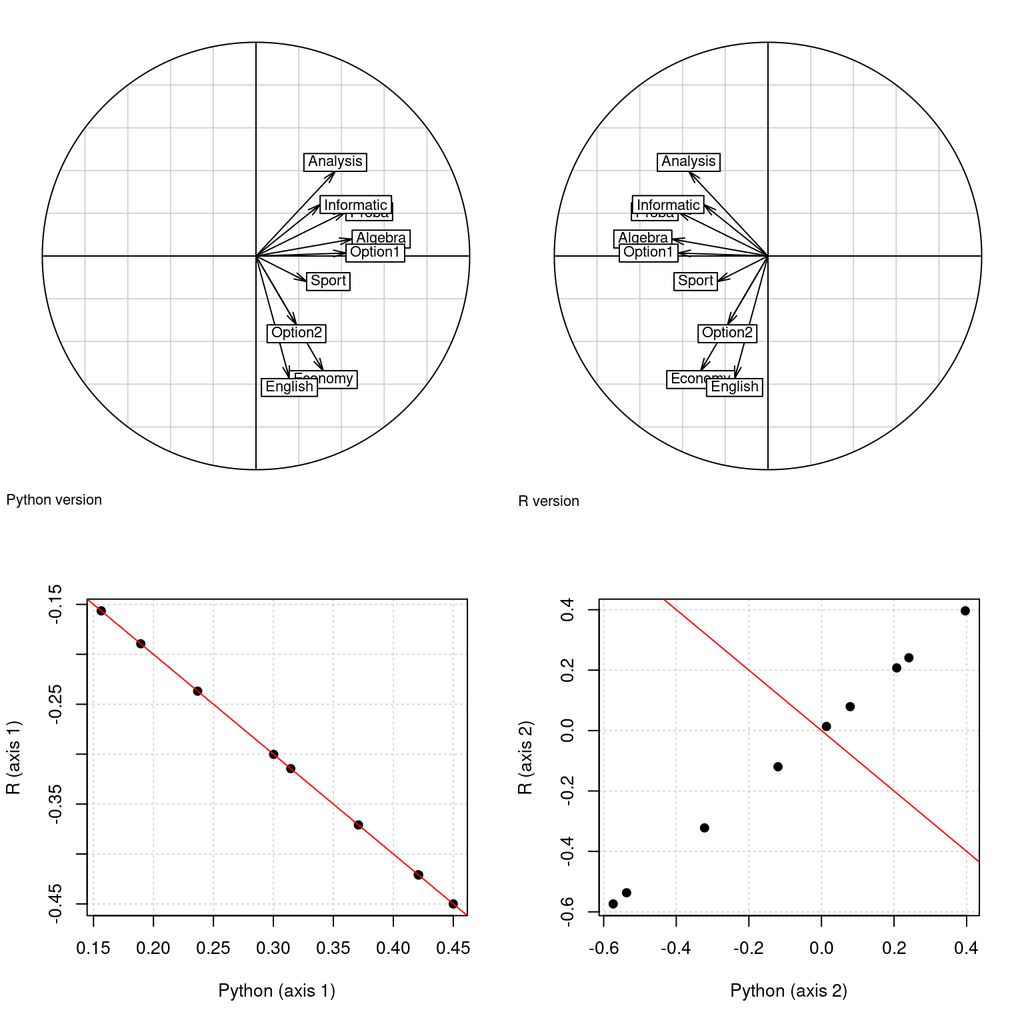

```r
library(reticulate)
library(ade4)
P <- py$P
colnames(P) <- paste("Axis",1:ncol(P),sep="")
rownames(P) <- colnames(py$deugtab)
par(mfrow=c(2,2))
s.corcircle(P,sub="Python version")
s.corcircle(pca2$c1,sub="R version")
plot(P[,1],pca2$c1[,1],panel.first=c(grid()),xlab="Python (axis 1)",ylab="R (axis 1)",pch=19);abline(0,-1,col="red")
plot(P[,2],pca2$c1[,2],panel.first=c(grid()),xlab="Python (axis 2)",ylab="R (axis 2)",pch=19);abline(0,-1,col="red")
```

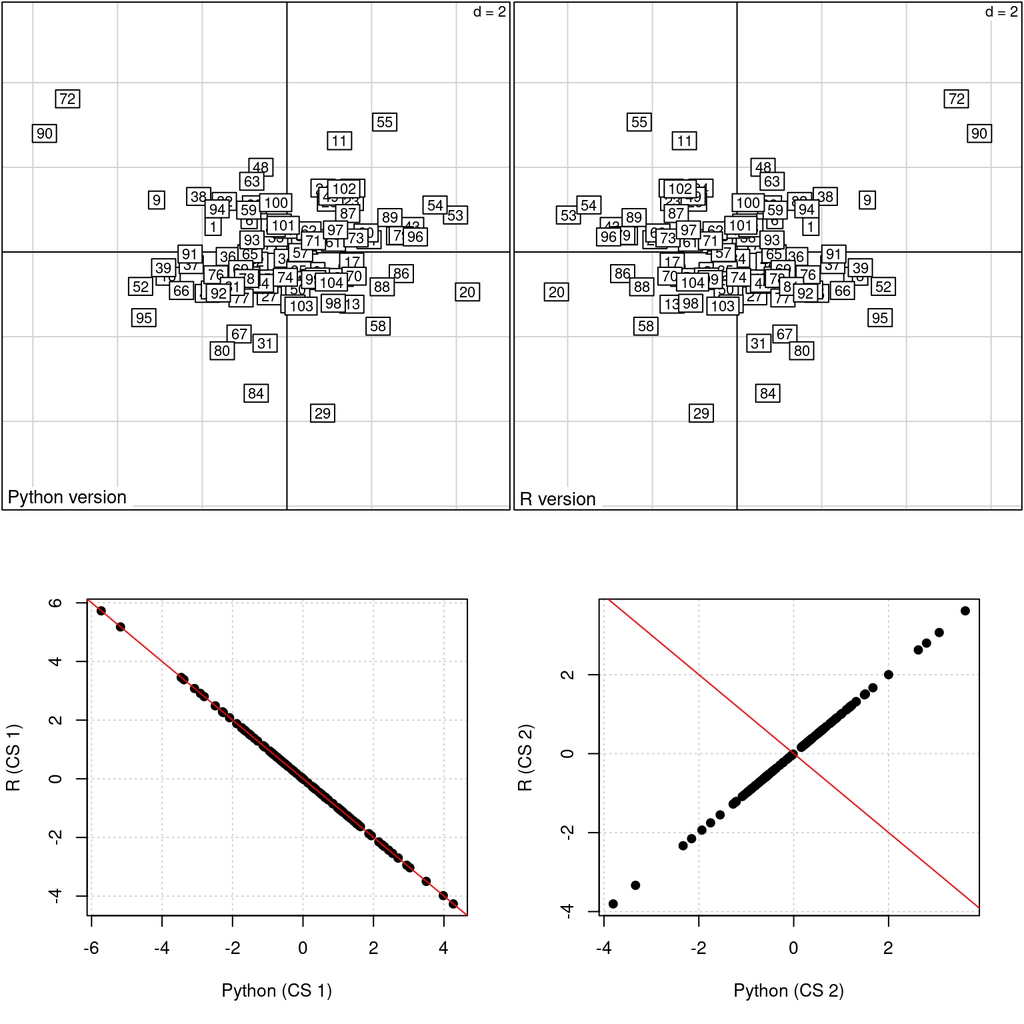

```r
coordli <- py$Z_new
colnames(coordli) <- paste("CS",1:ncol(coordli),sep="")
rownames(coordli) <- rownames(py$deugtab)
par(mfrow=c(2,2))
s.label(coordli,sub="Python version")
s.label(pca2$li,sub="R version")
plot(coordli[,1],pca2$li[,1],panel.first=c(grid()),xlab="Python (CS 1)",ylab="R (CS 1)",pch=19);abline(0,-1,col="red")
plot(coordli[,2],pca2$li[,2],panel.first=c(grid()),xlab="Python (CS 2)",ylab="R (CS 2)",pch=19);abline(0,-1,col="red")
```

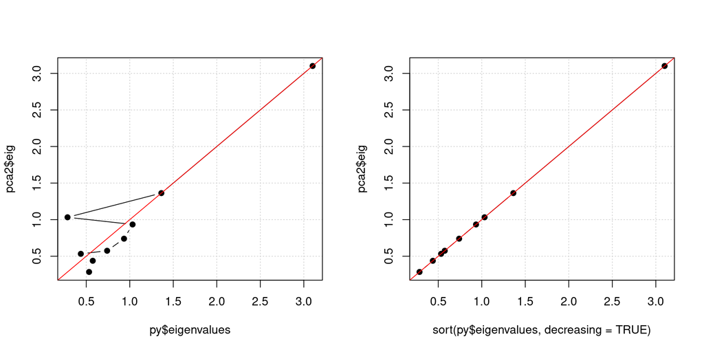

```r
par(mfrow=c(1,2))
plot(py$eigenvalues,pca2$eig,type="b",panel.first=c(grid()),pch=19); abline(0,1,col="red")
plot(sort(py$eigenvalues,decreasing = TRUE),pca2$eig,type="b",panel.first=c(grid()),pch=19); abline(0,1,col="red")
```

problem in the order of the eigenvalues !!!

```r
pca2$eig
```

```
## [1] 3.1013578 1.3629834 1.0323269 0.9340533 0.7397529 0.5746693 0.5325414
## [8] 0.4375395 0.2847754
```

```r
py$D
```

```
##           [,1]     [,2]      [,3]     [,4]      [,5]      [,6]      [,7]
##  [1,] 3.101358 0.000000 0.0000000 0.000000 0.0000000 0.0000000 0.0000000
##  [2,] 0.000000 1.362983 0.0000000 0.000000 0.0000000 0.0000000 0.0000000
##  [3,] 0.000000 0.000000 0.2847754 0.000000 0.0000000 0.0000000 0.0000000
##  [4,] 0.000000 0.000000 0.0000000 1.032327 0.0000000 0.0000000 0.0000000
##  [5,] 0.000000 0.000000 0.0000000 0.000000 0.9340533 0.0000000 0.0000000
##  [6,] 0.000000 0.000000 0.0000000 0.000000 0.0000000 0.7397529 0.0000000
##  [7,] 0.000000 0.000000 0.0000000 0.000000 0.0000000 0.0000000 0.4375395
##  [8,] 0.000000 0.000000 0.0000000 0.000000 0.0000000 0.0000000 0.0000000
##  [9,] 0.000000 0.000000 0.0000000 0.000000 0.0000000 0.0000000 0.0000000
##            [,8]      [,9]
##  [1,] 0.0000000 0.0000000
##  [2,] 0.0000000 0.0000000
##  [3,] 0.0000000 0.0000000
##  [4,] 0.0000000 0.0000000
##  [5,] 0.0000000 0.0000000
##  [6,] 0.0000000 0.0000000
##  [7,] 0.0000000 0.0000000
##  [8,] 0.5746693 0.0000000
##  [9,] 0.0000000 0.5325414
```

```r
py$eigenvalues
```

```
## [1] 3.1013578 1.3629834 0.2847754 1.0323269 0.9340533 0.7397529 0.4375395
## [8] 0.5746693 0.5325414
```

problem !!!

test of the pca from scikit-learn

```python
import sklearn.decomposition as sd
from sklearn.decomposition import PCA
pca = PCA(n_components=9)
Z2 = Z/np.sqrt(104)
pca.fit(Z2)
```

```
PCA(n_components=9)
```

```python
print(pca.explained_variance_ratio_)
```

```
## [0.34459531 0.1514426  0.11470299 0.1037837  0.08219477 0.06385214
##  0.05917127 0.0486155  0.03164171]
```

```python
print(pca.singular_values_)
```

```
## [1.76106724 1.16746882 1.01603489 0.96646433 0.86008891 0.75806943
##  0.72975436 0.66146771 0.5336435 ]
```

```python
print(pca.singular_values_*pca.singular_values_)
```

```
## [3.10135782 1.36298344 1.0323269  0.9340533  0.73975293 0.57466926
##  0.53254143 0.43753953 0.28477539]
```

# 5 Construction of the function “pydudi” (first prototype)

Back to top

based on the duality diagram (see more details below)

- https://pbil.univ-lyon1.fr/R/pdf/tdr61.pdf
- https://pbil.univ-lyon1.fr/R/pdf/stage3.pdf
- https://pbil.univ-lyon1.fr/R/pdf/bs8.pdf

first test => need to adjust the weighting (test with COA)

```python
import os
import string
import re
import pandas as pd
import numpy as np

def pydudi(X,cw,lw,nf):
  dim = X.shape
  n = dim[0]
  p = dim[1]
  nf0 = nf-1
  # n=len(X)
  # p=len(X.columns)
  D = np.diag(np.sqrt(lw))
  Q = np.diag(np.sqrt(cw))

  # XtDXQ => problem  with Q !!!

  XD = np.dot(X.T,D).T
  XD = np.dot(XD,Q)
  XtX = np.dot(XD.T,XD)


  # decomposition
  eigenvalues, eigenvectors = np.linalg.eig(XtX)
  index = np.argsort(eigenvalues)[::-1]

  # np.nonzero(eigenvalues)[0]
  eigenvalues = eigenvalues.real
  eigenvectors = eigenvectors.real
  eigenvalues=eigenvalues[index]
  eigenvectors=eigenvectors[:,index]
  # results
  rank = len(np.nonzero(eigenvalues)[0])
  C1 = np.dot(np.diag(1/np.sqrt(cw)),eigenvectors[:,0:nf])
  #C1 = eigenvectors[:,0:nf]
  XQ = np.dot(X,np.diag(cw))
  Li = np.dot(XQ, C1)

  # need to adjust the weighting (problem with sqrt)
  L1 = np.dot(Li,np.diag(1/np.sqrt(eigenvalues[0:nf])))
  Co = np.dot(C1,np.diag(np.sqrt(eigenvalues[0:nf])))
  return eigenvalues,rank,Li,L1,Co,C1,nf;

###
```

## 5.1 Test pydudi with PCA

```python
import numpy as np
import pandas as pd
deugtab = pd.read_csv('data/deugtab.csv')
deugtab
```

```
##      Unnamed: 0  Algebra  Analysis  Proba  ...  Option1  Option2  English  Sport
## 0             1       40      26.0     26  ...       17     24.0     19.0   11.5
## 1             2       37      34.5     37  ...       24     22.0     26.0   11.5
## 2             3       37      41.0     29  ...       24     27.0     19.6   11.5
## 3             4       63      37.5     57  ...       23     23.0     21.0   14.0
## 4             5       55      31.5     34  ...       19     24.0     24.0   11.5
## ..          ...      ...       ...    ...  ...      ...      ...      ...    ...
## 99          100       60      41.0     18  ...       20     24.0     17.2    0.0
## 100         101       48      44.0     22  ...       22     28.0     19.6    0.0
## 101         102       44      45.0     42  ...       27     22.0     18.4   15.0
## 102         103       47      32.0     26  ...       23     28.0     19.0   11.5
## 103         104       44      32.0     42  ...       28     27.5     23.0   11.5
##
## [104 rows x 10 columns]
```

```python
del deugtab['Unnamed: 0']
deugtab
```

```
##      Algebra  Analysis  Proba  Informatic  ...  Option1  Option2  English  Sport
## 0         40      26.0     26        26.0  ...       17     24.0     19.0   11.5
## 1         37      34.5     37        32.0  ...       24     22.0     26.0   11.5
## 2         37      41.0     29        34.5  ...       24     27.0     19.6   11.5
## 3         63      37.5     57        35.5  ...       23     23.0     21.0   14.0
## 4         55      31.5     34        36.0  ...       19     24.0     24.0   11.5
## ..       ...       ...    ...         ...  ...      ...      ...      ...    ...
## 99        60      41.0     18        30.0  ...       20     24.0     17.2    0.0
## 100       48      44.0     22        30.0  ...       22     28.0     19.6    0.0
## 101       44      45.0     42        35.0  ...       27     22.0     18.4   15.0
## 102       47      32.0     26        21.0  ...       23     28.0     19.0   11.5
## 103       44      32.0     42        26.5  ...       28     27.5     23.0   11.5
##
## [104 rows x 9 columns]
```

```python
X= deugtab - deugtab.mean()
# Normalize
X = X / X.std(ddof=0)
dim = X.shape
n = dim[0]
p = dim[1]
# lw = pd.DataFrame(np.repeat(1/len(X),len(X)))[0]
# cw = pd.DataFrame(np.repeat(1,len(X.columns)))[0]
lw = pd.DataFrame(np.repeat(1/n,n))[0]
cw = pd.DataFrame(np.repeat(1,p))[0]
ted = pydudi(X,cw,lw,2)
```

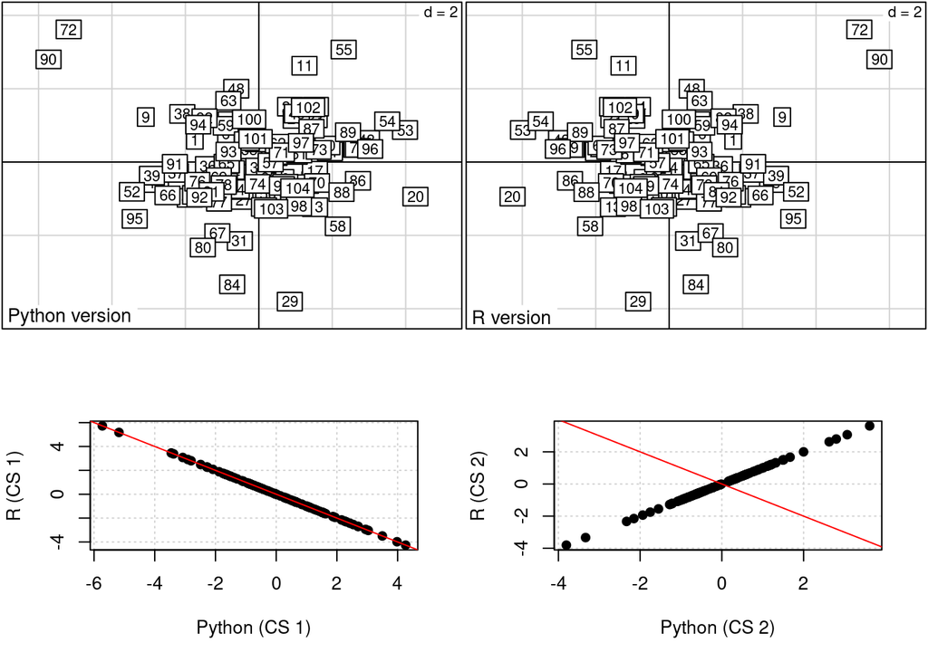

```r
library(reticulate)
names(py$ted) <- c("eig","rank","li","l1","co","c1","nf")
coordli <- py$ted$li
par(mfrow=c(2,2))
s.label(coordli,sub="Python version")
s.label(pca2$li,sub="R version")
plot(coordli[,1],pca2$li[,1],panel.first=c(grid()),xlab="Python (CS 1)",ylab="R (CS 1)",pch=19);abline(0,-1,col="red")
plot(coordli[,2],pca2$li[,2],panel.first=c(grid()),xlab="Python (CS 2)",ylab="R (CS 2)",pch=19);abline(0,-1,col="red")
```

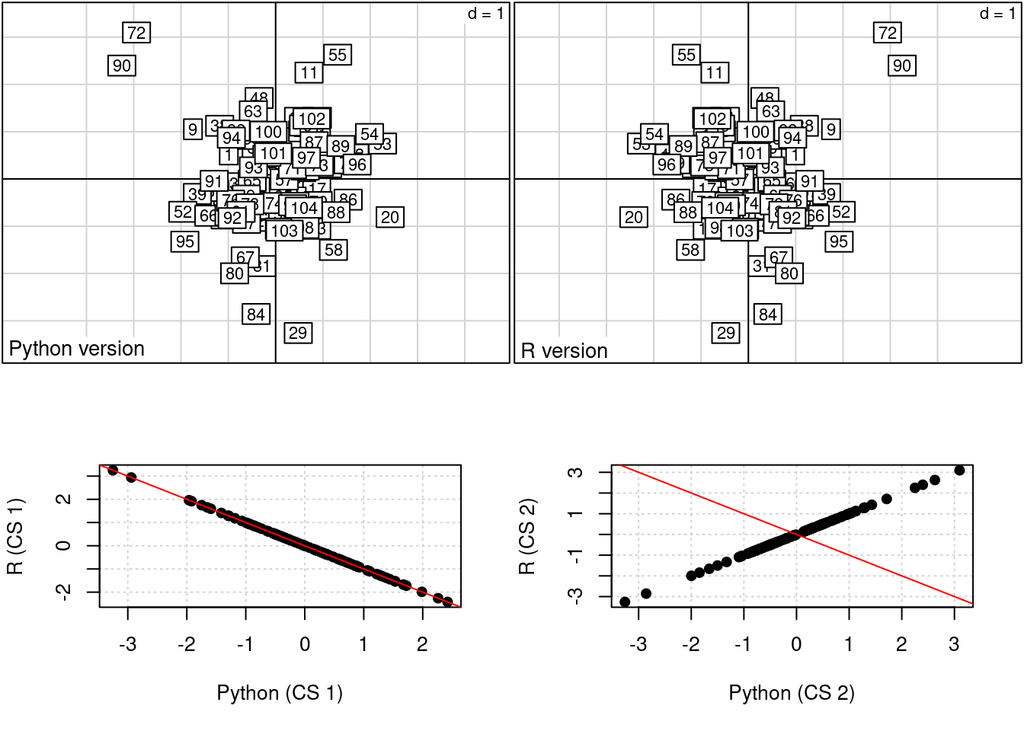

```r
coordl1 <- py$ted$l1
par(mfrow=c(2,2))
s.label(coordl1,sub="Python version")
s.label(pca2$l1,sub="R version")
plot(coordl1[,1],pca2$l1[,1],panel.first=c(grid()),xlab="Python (CS 1)",ylab="R (CS 1)",pch=19);abline(0,-1,col="red")
plot(coordl1[,2],pca2$l1[,2],panel.first=c(grid()),xlab="Python (CS 2)",ylab="R (CS 2)",pch=19);abline(0,-1,col="red")
```

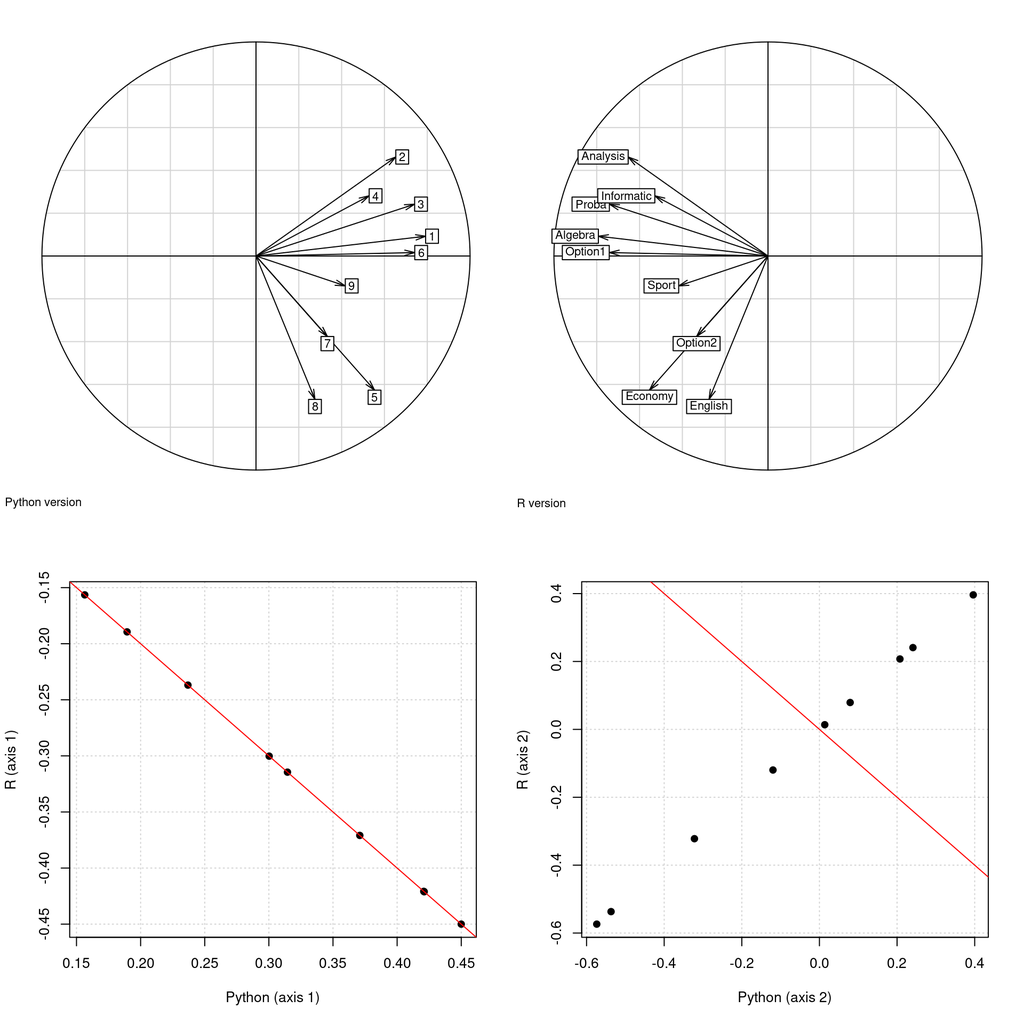

```r
par(mfrow=c(2,2))
s.corcircle(py$ted$co,sub="Python version")
s.corcircle(pca2$co,sub="R version")
plot(py$ted$c1[,1],pca2$c1[,1],panel.first=c(grid()),xlab="Python (axis 1)",ylab="R (axis 1)",pch=19);abline(0,-1,col="red")
plot(py$ted$c1[,2],pca2$c1[,2],panel.first=c(grid()),xlab="Python (axis 2)",ylab="R (axis 2)",pch=19);abline(0,-1,col="red")
```

## 5.2 Test pydudi with COA

COA: correspondence analysis.

```
 Benzécri, J.P. and Coll. (1973) _L'analyse des données. II
 L'analyse des correspondances_, Bordas, Paris. 1-620.

 Greenacre, M. J. (1984) _Theory and applications of correspondence
 analysis_, Academic Press, London.
```

Si R help from ade4 (dudi.coa) and https://pbil.univ-lyon1.fr/R/pdf/stage4.pdf

```r
data(rpjdl)
chisq.test(rpjdl$fau)$statistic
```

```
## X-squared
##  7323.597
```

```r
rpjdl.coa <- coa1 <- dudi.coa(rpjdl$fau, scannf = FALSE, nf = 4)
sum(rpjdl.coa$eig)*rpjdl.coa$N # the same
```

```
## [1] 7323.597
```

```r
write.csv(rpjdl$fau,file="data/fau.csv")
```

```python
# import numpy as np
import pandas as pd
fau = pd.read_csv('data/fau.csv')
fau
```

```
##      Unnamed: 0  AR  CP  ST  CC  UE  PV  JT  ...  CN  SS  FC  MC  EC  EH  El  PD
## 0             1   0   0   0   0   0   0   0  ...   1   0   0   0   0   0   0   1
## 1             2   0   0   0   0   0   0   0  ...   0   1   0   0   0   0   0   0
## 2             3   0   0   0   0   1   0   0  ...   1   1   0   0   0   0   1   0
## 3             4   0   0   0   0   0   0   0  ...   1   0   0   0   0   0   0   0
## 4             5   1   0   0   0   0   0   0  ...   0   0   0   0   0   0   0   0
## ..          ...  ..  ..  ..  ..  ..  ..  ..  ...  ..  ..  ..  ..  ..  ..  ..  ..
## 177         178   0   0   0   0   0   0   0  ...   0   0   0   0   0   0   0   0
## 178         179   0   0   0   0   0   0   0  ...   0   0   1   0   0   0   0   0
## 179         180   0   0   0   0   0   1   0  ...   0   1   1   0   0   0   0   0
## 180         181   0   0   1   0   0   0   1  ...   0   1   0   0   0   0   0   0
## 181         182   0   0   0   0   0   0   0  ...   0   1   1   0   1   0   0   0
##
## [182 rows x 52 columns]
```

```python
del fau['Unnamed: 0']
fau
```

```
##      AR  CP  ST  CC  UE  PV  JT  GT  LA  ...  CA  CN  SS  FC  MC  EC  EH  El  PD
## 0     0   0   0   0   0   0   0   0   0  ...   1   1   0   0   0   0   0   0   1
## 1     0   0   0   0   0   0   0   1   0  ...   1   0   1   0   0   0   0   0   0
## 2     0   0   0   0   1   0   0   0   0  ...   0   1   1   0   0   0   0   1   0
## 3     0   0   0   0   0   0   0   0   0  ...   0   1   0   0   0   0   0   0   0
## 4     1   0   0   0   0   0   0   1   0  ...   1   0   0   0   0   0   0   0   0
## ..   ..  ..  ..  ..  ..  ..  ..  ..  ..  ...  ..  ..  ..  ..  ..  ..  ..  ..  ..
## 177   0   0   0   0   0   0   0   0   0  ...   0   0   0   0   0   0   0   0   0
## 178   0   0   0   0   0   0   0   0   0  ...   0   0   0   1   0   0   0   0   0
## 179   0   0   0   0   0   1   0   0   0  ...   0   0   1   1   0   0   0   0   0
## 180   0   0   1   0   0   0   1   0   0  ...   0   0   1   0   0   0   0   0   0
## 181   0   0   0   0   0   0   0   0   0  ...   0   0   1   1   0   1   0   0   0
##
## [182 rows x 51 columns]
```

```python
import numpy as np

X=fau
sumX = fau.sum().sum()
sumCol =  fau.sum(axis=0)
sumRow = fau.sum(axis=1)

pij = X/sumX
pi = sumRow/sumX
pj = sumCol/sumX

Dj = np.diag(1/pj)
Di = np.diag(1/pi)

Z = np.dot(Di,pij)
Z= np.dot(Z,Dj)
Z.shape
```

```
## (182, 51)
```

```python
Z =Z - 1
Z = np.nan_to_num(Z)

# Normalize
lw = pi
cw = pj
D= np.diag(np.sqrt(pi))
Q= np.diag(np.sqrt(pj))
X =Z
ted = pydudi(Z,cw,lw,2)
```

```r
require(reticulate)
names(py$ted) <- c("eig","rank","li","l1","co","c1","nf")
```

```r
head(t(t(py$X)%*%py$D))[,1]
```

```
## [1] -0.06986433 -0.06986433 -0.06535210 -0.04940154  0.85002979  0.76588343
```

```r
head(py$X*diag(py$D))[,1]
```

```
## [1] -0.06986433 -0.06986433 -0.06535210 -0.04940154  0.85002979  0.76588343
```

```r
XD <- t(t(py$X)%*%py$D)
head(XD%*%py$Q)[,1]
```

```
## [1] -0.007717578 -0.007717578 -0.007219133 -0.005457152  0.093898719
## [6]  0.084603474
```

```r
head(sweep(XD,2,diag(py$Q),"*"))[,1]
```

```
## [1] -0.007717578 -0.007717578 -0.007219133 -0.005457152  0.093898719
## [6]  0.084603474
```

```r
coa1$eig
```

```
##  [1] 0.753246079 0.292905714 0.229339077 0.204667043 0.157288711 0.151440858
##  [7] 0.150767524 0.139271459 0.128099632 0.121613888 0.117678929 0.114349277
## [13] 0.111133629 0.108686867 0.104567293 0.098786861 0.093491391 0.089476206
## [19] 0.083038229 0.078627728 0.071855317 0.066171912 0.064569801 0.063747501
## [25] 0.061830129 0.056205831 0.054891709 0.051264371 0.051057282 0.048112526
## [31] 0.047741238 0.045225569 0.042174679 0.041081123 0.039945517 0.037205530
## [37] 0.034420610 0.031713688 0.029256753 0.027162167 0.026386209 0.022092347
## [43] 0.021089820 0.020517411 0.016786030 0.016066325 0.015476722 0.014463573
## [49] 0.012991222 0.008353461
```

```r
py$ted$eig
```

```
##  [1]  7.532461e-01  2.929057e-01  2.293391e-01  2.046670e-01  1.572887e-01
##  [6]  1.514409e-01  1.507675e-01  1.392715e-01  1.280996e-01  1.216139e-01
## [11]  1.176789e-01  1.143493e-01  1.111336e-01  1.086869e-01  1.045673e-01
## [16]  9.878686e-02  9.349139e-02  8.947621e-02  8.303823e-02  7.862773e-02
## [21]  7.185532e-02  6.617191e-02  6.456980e-02  6.374750e-02  6.183013e-02
## [26]  5.620583e-02  5.489171e-02  5.126437e-02  5.105728e-02  4.811253e-02
## [31]  4.774124e-02  4.522557e-02  4.217468e-02  4.108112e-02  3.994552e-02
## [36]  3.720553e-02  3.442061e-02  3.171369e-02  2.925675e-02  2.716217e-02
## [41]  2.638621e-02  2.209235e-02  2.108982e-02  2.051741e-02  1.678603e-02
## [46]  1.606633e-02  1.547672e-02  1.446357e-02  1.299122e-02  8.353461e-03
## [51] -1.964766e-17
```

ok for the eigenvalues, probleme dans le calcul des coordonnées ???

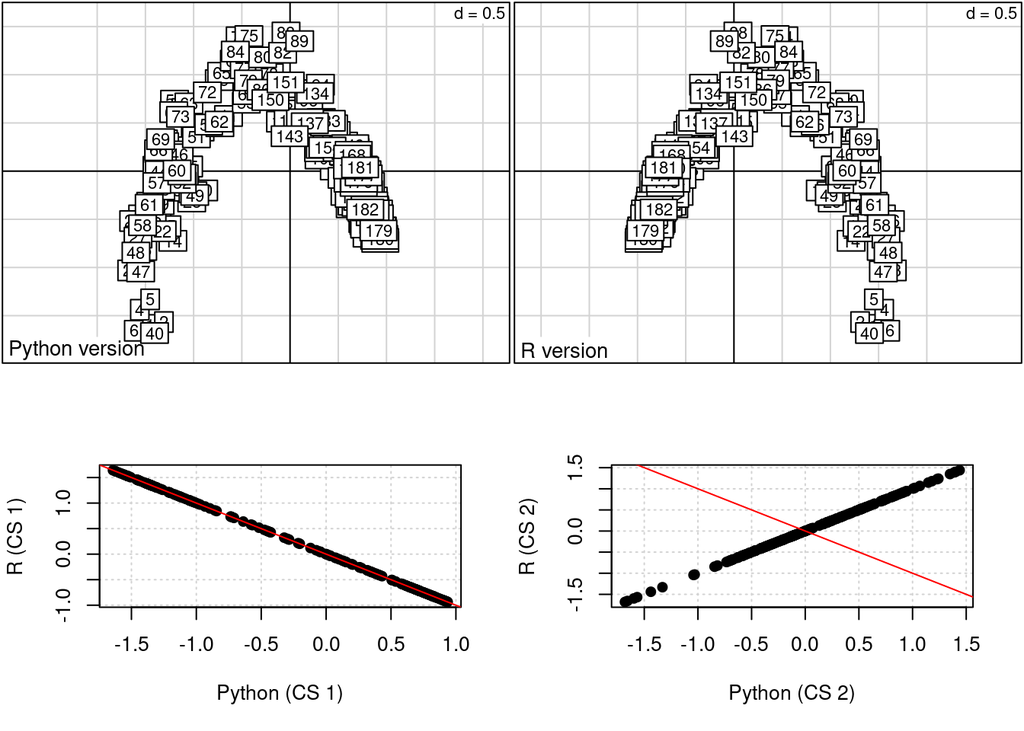

```r
coordli <- py$ted$li
par(mfrow=c(2,2))
s.label(coordli,sub="Python version")
s.label(coa1$li,sub="R version")
plot(coordli[,1],coa1$li[,1],panel.first=c(grid()),xlab="Python (CS 1)",ylab="R (CS 1)",pch=19);abline(0,-1,col="red")
plot(coordli[,2],coa1$li[,2],panel.first=c(grid()),xlab="Python (CS 2)",ylab="R (CS 2)",pch=19);abline(0,-1,col="red")
```

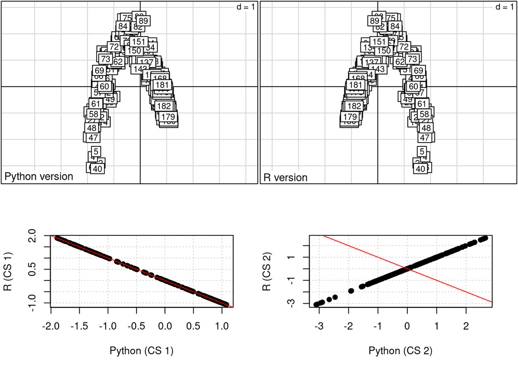

```r
coordl1 <- py$ted$l1
par(mfrow=c(2,2))
s.label(coordl1,sub="Python version")
s.label(coa1$l1,sub="R version")
plot(coordl1[,1],coa1$l1[,1],panel.first=c(grid()),xlab="Python (CS 1)",ylab="R (CS 1)",pch=19);abline(0,-1,col="red")
plot(coordl1[,2],coa1$l1[,2],panel.first=c(grid()),xlab="Python (CS 2)",ylab="R (CS 2)",pch=19);abline(0,-1,col="red")
```

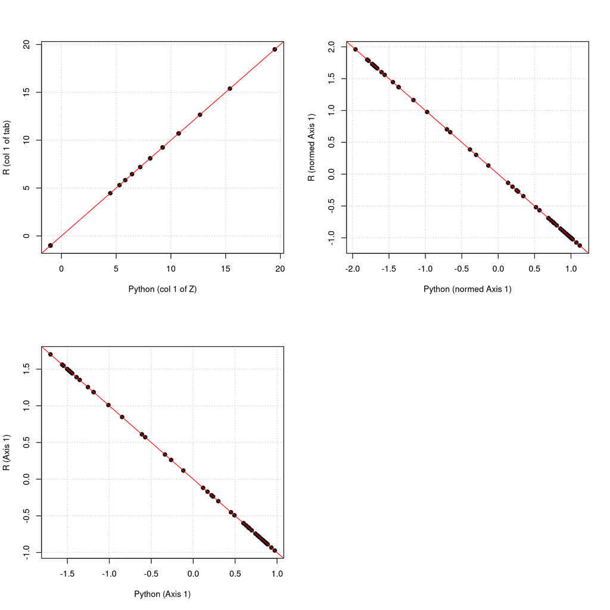

```r
par(mfrow=c(2,2))
plot(py$Z[,1],coa1$tab[,1],panel.first=c(grid()),xlab="Python (col 1 of Z)",ylab="R (col 1 of tab)",pch=19);abline(0,1,col="red")
plot(py$ted$c1[,1],coa1$c1[,1],panel.first=c(grid()),xlab="Python (normed Axis 1)",ylab="R (normed Axis 1)",pch=19);abline(0,-1,col="red")
plot(py$ted$co[,1],coa1$co[,1],panel.first=c(grid()),xlab="Python (Axis 1)",ylab="R (Axis 1)",pch=19);abline(0,-1,col="red")
```

=> need to check the weight !!! => Ok !!

## 5.3 Test pydudi with MCA

MCA: Multiple Correspondence Analysis

```
Tenenhaus, M. & Young, F.W. (1985) An analysis and synthesis of multiple correspondence analysis, optimal scaling, dual scaling, homogeneity analysis ans other     methods for quantifying categorical multivariate data. Psychometrika, 50, 1, 91-119.
Lebart, L., A. Morineau, and M. Piron. 1995. Statistique exploratoire multidimensionnelle. Dunod, Paris.
```

Si R help from ade4 (dudi.acm) and https://pbil.univ-lyon1.fr/R/pdf/stage4.pdf. the description of the methods is given below:

- https://pbil.univ-lyon1.fr/R/pdf/tdr521.pdf
- https://pbil.univ-lyon1.fr/R/pdf/tdr52.pdf

duality diagram

```r
data(ours)
summary(ours)
```

```
##  altit  deniv  cloiso domain boise  hetra  favor  inexp  citat  depart
##  1: 8   1:13   1:12   1: 9   1:10   1:19   1:15   1:20   1:22   AHP:5
##  2:17   2:14   2: 4   2:13   2:15   2: 5   2:12   2:10   2: 7   AM :4
##  3:13   3:11   3:22   3:16   3:13   3:14   3:11   3: 8   3: 4   D  :5
##                                                          4: 5   HP :8
##                                                                 HS :4
##                                                                 I  :5
##                                                                 S  :7
```

```r
acm1 <- dudi.acm(ours, scan = FALSE)
```

```r
write.csv(ours,file="data/ours.csv")
```

importation with pandas

```python
# import numpy as np
import pandas as pd
ours = pd.read_csv('data/ours.csv')
ours
```

```
##     Unnamed: 0  altit  deniv  cloiso  domain  ...  hetra  favor  inexp  citat  depart
## 0            1      2      3       3       2  ...      3      3      2      1      HS
## 1            2      1      2       1       2  ...      1      2      2      2      HS
## 2            3      3      3       3       2  ...      2      3      3      2      HS
## 3            4      3      3       3       1  ...      3      3      2      3      HS
## 4            5      3      3       1       2  ...      3      2      3      1       S
## 5            6      3      3       3       1  ...      3      3      3      3       S
## 6            7      2      2       3       2  ...      1      2      3      1       S
## 7            8      1      1       2       2  ...      1      3      2      2       S
## 8            9      2      3       1       2  ...      2      3      3      4       S
## 9           10      2      2       3       1  ...      3      2      3      1       S
## 10          11      1      1       1       1  ...      1      2      2      1       S
## 11          12      2      2       3       1  ...      3      3      2      3       I
## 12          13      2      3       3       1  ...      3      3      2      3       I
## 13          14      1      3       2       2  ...      1      1      3      2       I
```

[output cut: 26 more lines]

```python
del ours['Unnamed: 0']
ours
```

```
##     altit  deniv  cloiso  domain  boise  hetra  favor  inexp  citat depart
## 0       2      3       3       2      2      3      3      2      1     HS
## 1       1      2       1       2      1      1      2      2      2     HS
## 2       3      3       3       2      2      2      3      3      2     HS
## 3       3      3       3       1      3      3      3      2      3     HS
## 4       3      3       1       2      2      3      2      3      1      S
## 5       3      3       3       1      3      3      3      3      3      S
## 6       2      2       3       2      2      1      2      3      1      S
## 7       1      1       2       2      1      1      3      2      2      S
## 8       2      3       1       2      3      2      3      3      4      S
## 9       2      2       3       1      3      3      2      3      1      S
## 10      1      1       1       1      1      1      2      2      1      S
## 11      2      2       3       1      3      3      3      2      3      I
## 12      2      3       3       1      3      3      3      2      3      I
## 13      1      3       2       2      1      1      1      3      2      I
```

[output cut: 24 more lines]

```python
def disjonctif(X):
  X_cat = X.astype("category")
  X_dis = pd.get_dummies(X_cat)
  X_dis = X_dis*1
  return X_dis ;
```

preparation of the triplet

```python
Xdis = disjonctif(ours)
m = Xdis.shape[1]
n = Xdis.shape[0]
v = ours.shape[1]
lw = pd.DataFrame(np.repeat(1/n,n))[0]
D = np.diag(lw)
cw = np.dot(np.dot(Xdis.T,D), np.ones(n))
Dm = np.diag(cw)
X = np.dot(Xdis,np.diag(1/cw))-1
cw = cw/v
ted = pydudi(X,cw,lw,2)
```

```r
require(reticulate)
names(py$ted) <- c("eig","rank","li","l1","co","c1","nf")
```

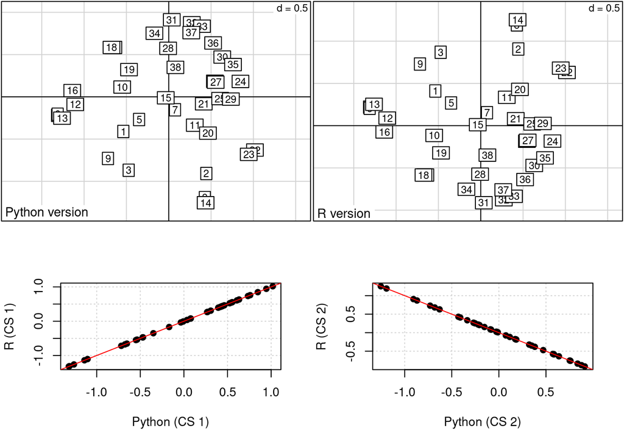

```r
coordli <- py$ted$li
par(mfrow=c(2,2))
s.label(coordli,sub="Python version")
s.label(acm1$li,sub="R version")
plot(coordli[,1],acm1$li[,1],panel.first=c(grid()),xlab="Python (CS 1)",ylab="R (CS 1)",pch=19);abline(0,1,col="red")
plot(coordli[,2],acm1$li[,2],panel.first=c(grid()),xlab="Python (CS 2)",ylab="R (CS 2)",pch=19);abline(0,-1,col="red")
```

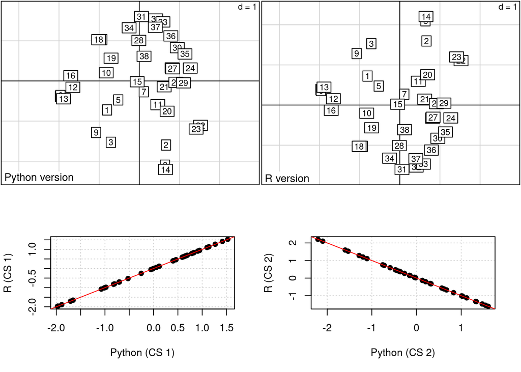

```r
coordl1 <- py$ted$l1
par(mfrow=c(2,2))
s.label(coordl1,sub="Python version")
s.label(acm1$l1,sub="R version")
plot(coordl1[,1],acm1$l1[,1],panel.first=c(grid()),xlab="Python (CS 1)",ylab="R (CS 1)",pch=19);abline(0,1,col="red")
plot(coordl1[,2],acm1$l1[,2],panel.first=c(grid()),xlab="Python (CS 2)",ylab="R (CS 2)",pch=19);abline(0,-1,col="red")
```

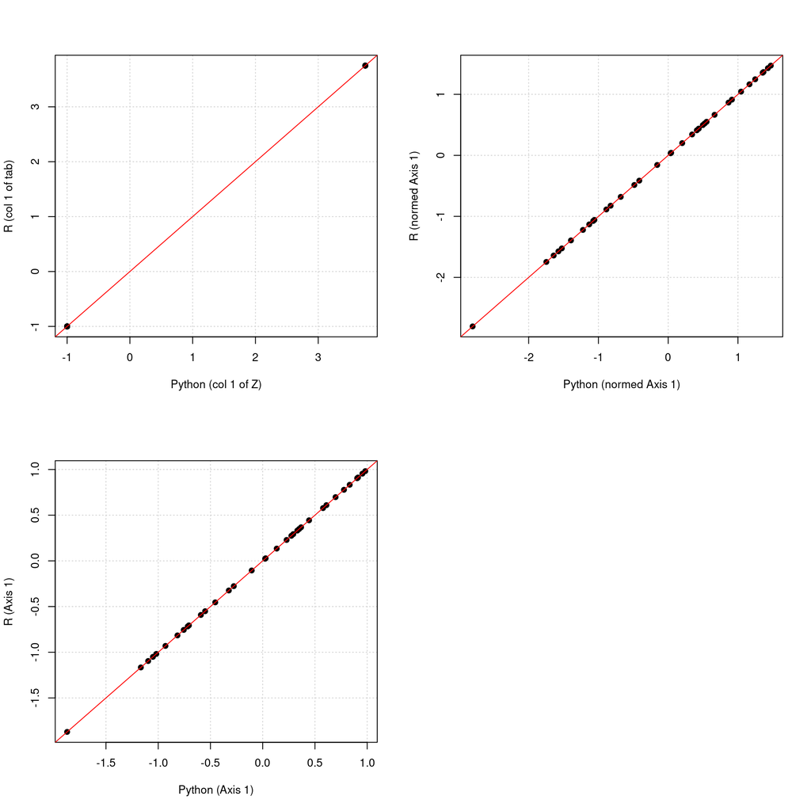

```r
par(mfrow=c(2,2))
plot(py$X[,1],acm1$tab[,1],panel.first=c(grid()),xlab="Python (col 1 of Z)",ylab="R (col 1 of tab)",pch=19);abline(0,1,col="red")
plot(py$ted$c1[,1],acm1$c1[,1],panel.first=c(grid()),xlab="Python (normed Axis 1)",ylab="R (normed Axis 1)",pch=19);abline(0,1,col="red")
plot(py$ted$co[,1],acm1$co[,1],panel.first=c(grid()),xlab="Python (Axis 1)",ylab="R (Axis 1)",pch=19);abline(0,1,col="red")
```

# 6 Class and object dudi

Back to top

define the structure of the object and description of the elements based on object ‘dudi’ from R package ade4 (and ADE-4):

- tab
- eig
- rank
- c1
- co
- l1
- li

heritage for the PCA and COA (and other methods):

- tab
- lw
- cw
- dudi
- and specific elements

## 6.1 Object **Dudi**

```python
class Dudi:
  def __init__(self,tab,cw,lw,eig,rank,nf,c1,co,l1,li):
    self.tab = tab
    self.cw = cw
    self.lw = lw
    self.eig = eig
    self.rank = rank
    self.nf = nf
    self.c1 = c1
    self.co = co
    self.l1 = l1
    self.li = li

def pyDudi(X,cw,lw,nf):
  dim = X.shape
  n = dim[0]
  p = dim[1]
  nf0 = nf-1
  # n=len(X)
  # p=len(X.columns)
  D = np.diag(np.sqrt(lw))
  Q = np.diag(np.sqrt(cw))

  # XtDXQ => problem  with Q !!!
  XD = np.dot(X.T,D).T
  XD = np.dot(XD,Q)
  XtX = np.dot(XD.T,XD)

  # decomposition
  eigenvalues, eigenvectors = np.linalg.eig(XtX)
  index = np.argsort(eigenvalues)[::-1]

  # np.nonzero(eigenvalues)[0]
  eigenvalues = eigenvalues.real
  eigenvectors = eigenvectors.real
  eigenvalues=eigenvalues[index]
  eigenvectors=eigenvectors[:,index]
  # results
  rank = len(np.nonzero(eigenvalues)[0])
  C1 = np.dot(np.diag(1/np.sqrt(cw)),eigenvectors[:,0:nf])
  #C1 = eigenvectors[:,0:nf]
  XQ = np.dot(X,np.diag(cw))
  Li = np.dot(XQ, C1)

  # need to adjust the weighting (problem with sqrt)
  L1 = np.dot(Li,np.diag(1/np.sqrt(eigenvalues[0:nf])))
  Co = np.dot(C1,np.diag(np.sqrt(eigenvalues[0:nf])))
  return Dudi(X,cw,lw,eigenvalues,rank,nf,C1,Co,L1,Li);
```

## 6.2 test pour PCA

```python
def pyPCA(X,cw=None,lw=None,nf=2,center=True,scale=True):
  dim = X.shape
  n = dim[0]
  p = dim[1]
  if center:
    X = X-X.mean()
  if scale:
    X = X/X.std(ddof=0)
  if lw==None :
    lw = pd.DataFrame(np.repeat(1/n,n))[0]
  if cw==None :
    cw = pd.DataFrame(np.repeat(1,p))[0]
  dudi = pyDudi(X,cw,lw,nf)
  return dudi;
```

```python
pca1 = pyPCA(deugtab)
```

## 6.3 test pour COA

```python
def pyCOA(X,nf=2):
  sumX = X.sum().sum()
  sumCol =  X.sum(axis=0)
  sumRow = X.sum(axis=1)
  pij = X/sumX
  pi = sumRow/sumX
  pj = sumCol/sumX
  Dj = np.diag(1/pj)
  Di = np.diag(1/pi)
  Z = np.dot(Di,pij)
  Z = np.dot(Z,Dj)
  Z = Z - 1
  Z = np.nan_to_num(Z)
  dudi = pyDudi(Z,pj,pi,nf)
  return dudi;
```

```python
coa1 = pyCOA(fau)
```

## 6.4 test pour ACM

```python
def disjonctif(X):
  X_cat = X.astype("category")
  X_dis = pd.get_dummies(X_cat)
  X_dis = X_dis*1
  return X_dis;

def pyACM(X,lw=None,nf=2):
  Xdis = disjonctif(ours)
  m = Xdis.shape[1]
  n = Xdis.shape[0]
  v = ours.shape[1]
  if lw==None :
    lw = pd.DataFrame(np.repeat(1/n,n))[0]
  D = np.diag(lw)
  cw = np.dot(np.dot(Xdis.T,D), np.ones(n))
  Dm = np.diag(cw)
  X = np.dot(Xdis,np.diag(1/cw))-1
  cw = cw/v
  dudi = pyDudi(X,cw,lw,nf)
  return dudi;
```

```python
mca1 = pyACM(ours)
```

## 6.5 Generate Python package called pydudi

construction of the file called ‘setup.py’ in the folder

```
from setuptools import setup, find_packages
setup(
    name='pydudi',
    version='1.0',
    packages=find_packages(),
    description='Implementation Test of the duality diagram based on ade4 works',
    author='Pierre Bady',
    author_email='pierre.bady@gmail.com',
    install_requires=[],
)
```

contruction of the file “**init**.py” in the subfolder

```
__all__ = ["Ktab","pyACM","pyCOA","pyDudi","pyPCA"]
```

constrcution nof the archive (deprecated!!!)

```
python setup.py sdist bdist_wheel
```

it’s recommanded to use the following code (see: https://blog.stephane-robert.info/docs/developper/programmation/python/modules/)

```
pip install build twine
python -m build          # ou : uv build
twine upload dist/*      # authentification par jeton API PyPI
```

# 7 Construction of the function dudi in Rcpp

## 7.1 Test Rcpp: correlation between two variables

```r
require(parallel)
require(Rcpp)
require(RcppArmadillo)
#Sys.setenv("PKG_CXXFLAGS"="-fopenmp")
#Sys.setenv("PKG_LIBS"="-fopenmp")
sourceCpp(file.path(getwd(),"src","utility.cpp"))
```

correlation coefficient

```r
cor(1:10, 2:11)
```

```
## [1] 1
```

```r
CORR(1:10, 2:11)
```

```
## [1] 1
```

computation of the area under curve

## 7.2 Object dudi

dudi obect with Rcpparmadillo

```r
sourceCpp(file.path(getwd(),"src","utility.cpp"))
pca2 <- dudi.pca(deug$tab, center = TRUE, scale = TRUE, scan = FALSE)
test <- arc_dudi(as.matrix(pca2$tab),pca2$cw,pca2$lw,2)
test$eig
```

```
##            [,1]
##  [1,] 3.1013578
##  [2,] 1.3629834
##  [3,] 1.0323269
##  [4,] 0.9340533
##  [5,] 0.7397529
##  [6,] 0.5746693
##  [7,] 0.5325414
##  [8,] 0.4375395
##  [9,] 0.2847754
```

```r
pca2$eig
```

```
## [1] 3.1013578 1.3629834 1.0323269 0.9340533 0.7397529 0.5746693 0.5325414
## [8] 0.4375395 0.2847754
```

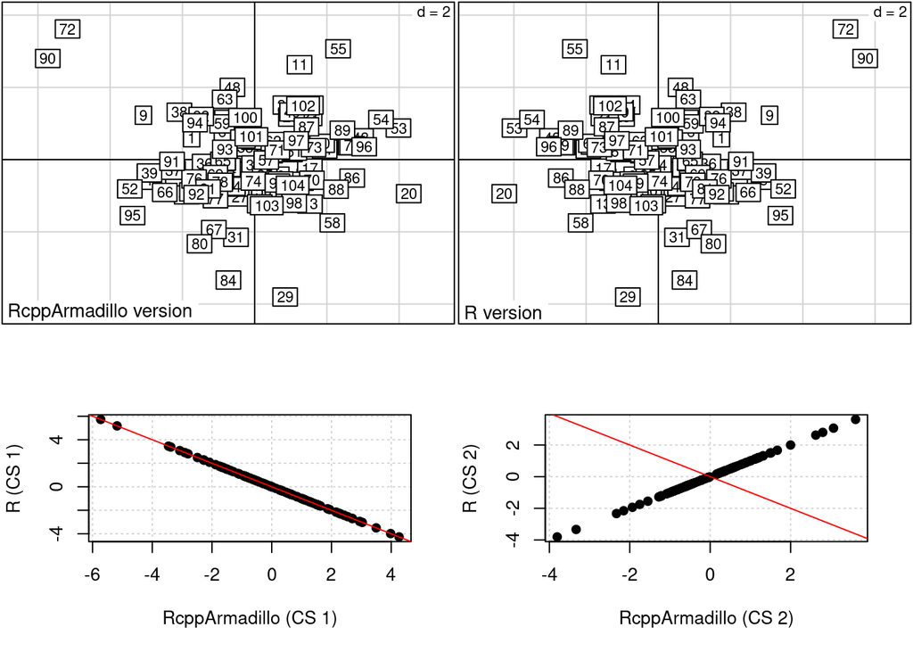

```r
coordli <- test$li
par(mfrow=c(2,2))
s.label(coordli,sub="RcppArmadillo version")
s.label(pca2$li,sub="R version")
plot(coordli[,1],pca2$li[,1],panel.first=c(grid()),xlab="RcppArmadillo (CS 1)",ylab="R (CS 1)",pch=19);abline(0,-1,col="red")
plot(coordli[,2],pca2$li[,2],panel.first=c(grid()),xlab="RcppArmadillo (CS 2)",ylab="R (CS 2)",pch=19);abline(0,-1,col="red")
```

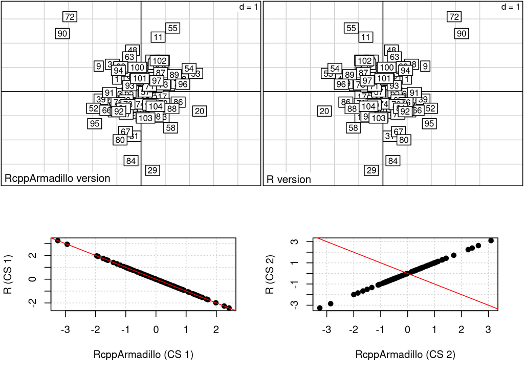

```r
coordl1 <- test$l1
par(mfrow=c(2,2))
s.label(coordl1,sub="RcppArmadillo version")
s.label(pca2$l1,sub="R version")
plot(coordl1[,1],pca2$l1[,1],panel.first=c(grid()),xlab="RcppArmadillo (CS 1)",ylab="R (CS 1)",pch=19);abline(0,-1,col="red")
plot(coordl1[,2],pca2$l1[,2],panel.first=c(grid()),xlab="RcppArmadillo (CS 2)",ylab="R (CS 2)",pch=19);abline(0,-1,col="red")
```

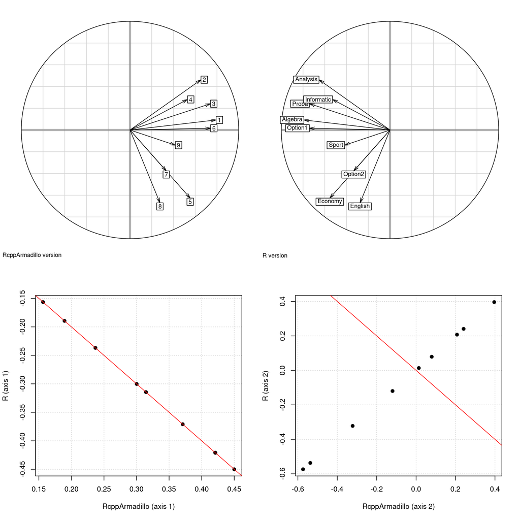

```r
par(mfrow=c(2,2))
s.corcircle(test$co,sub="RcppArmadillo version")
s.corcircle(pca2$co,sub="R version")
plot(test$c1[,1],pca2$c1[,1],panel.first=c(grid()),xlab="RcppArmadillo (axis 1)",ylab="R (axis 1)",pch=19);abline(0,-1,col="red")
plot(test$c1[,2],pca2$c1[,2],panel.first=c(grid()),xlab="RcppArmadillo (axis 2)",ylab="R (axis 2)",pch=19);abline(0,-1,col="red")
```

## 7.3 Test PCA

argument for the function cpca:

- X: matrix
- cw: numeric vector corresponding to the column weighting
- lw: numeric vector corresponding to the row weighting
- nf: number of selected axes
- center: 1 for TRUE, 0 for FALSE
- scale: 1 for TRUE, 0 for FALSE

```r
sourceCpp(file.path(getwd(),"src","utility.cpp"))
test2 <- arc_pca(as.matrix(deug$tab),pca2$cw,pca2$lw,2,1,1)
pca2$eig
```

```
## [1] 3.1013578 1.3629834 1.0323269 0.9340533 0.7397529 0.5746693 0.5325414
## [8] 0.4375395 0.2847754
```

```r
test2$eig
```

```
##            [,1]
##  [1,] 3.1013578
##  [2,] 1.3629834
##  [3,] 1.0323269
##  [4,] 0.9340533
##  [5,] 0.7397529
##  [6,] 0.5746693
##  [7,] 0.5325414
##  [8,] 0.4375395
##  [9,] 0.2847754
```

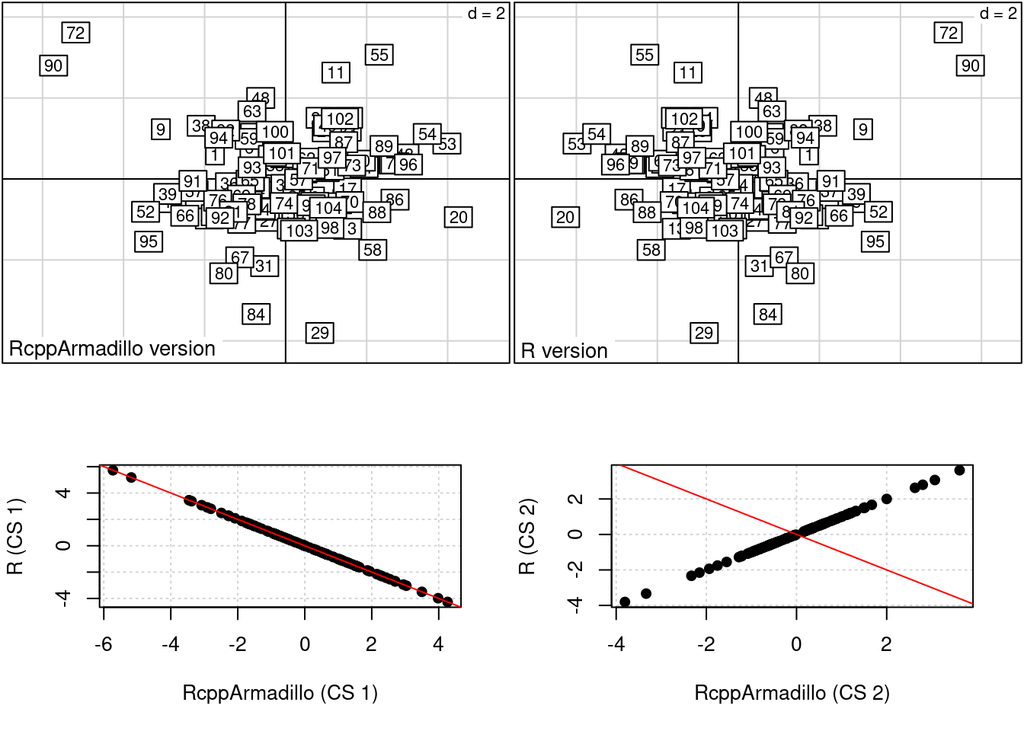

```r
coordli <- test2$li
par(mfrow=c(2,2))
s.label(coordli,sub="RcppArmadillo version")
s.label(pca2$li,sub="R version")
plot(coordli[,1],pca2$li[,1],panel.first=c(grid()),xlab="RcppArmadillo (CS 1)",ylab="R (CS 1)",pch=19);abline(0,-1,col="red")
plot(coordli[,2],pca2$li[,2],panel.first=c(grid()),xlab="RcppArmadillo (CS 2)",ylab="R (CS 2)",pch=19);abline(0,-1,col="red")
```

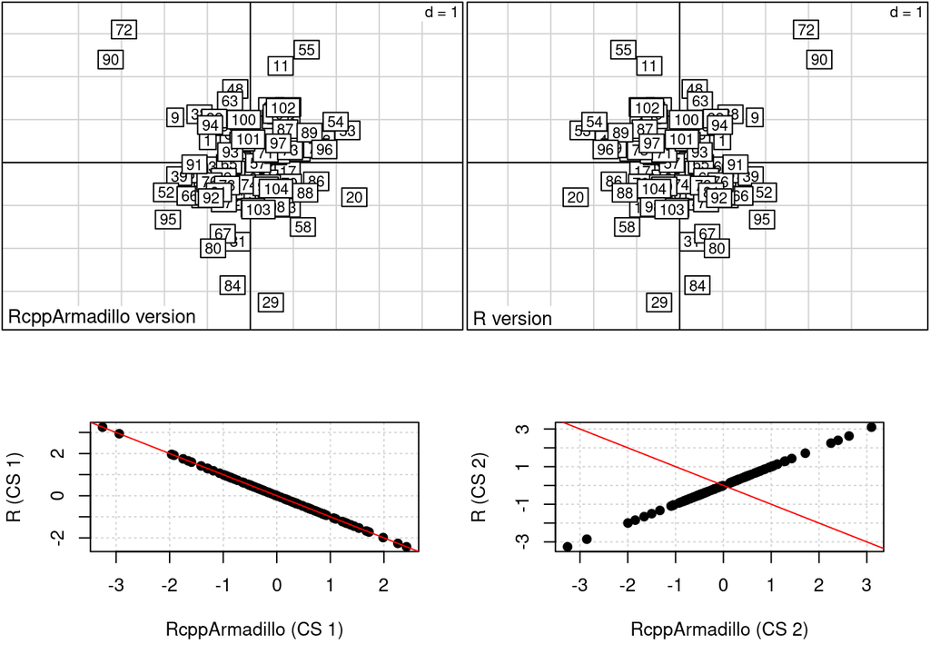

```r
coordl1 <- test2$l1
par(mfrow=c(2,2))
s.label(coordl1,sub="RcppArmadillo version")
s.label(pca2$l1,sub="R version")
plot(coordl1[,1],pca2$l1[,1],panel.first=c(grid()),xlab="RcppArmadillo (CS 1)",ylab="R (CS 1)",pch=19);abline(0,-1,col="red")
plot(coordl1[,2],pca2$l1[,2],panel.first=c(grid()),xlab="RcppArmadillo (CS 2)",ylab="R (CS 2)",pch=19);abline(0,-1,col="red")
```

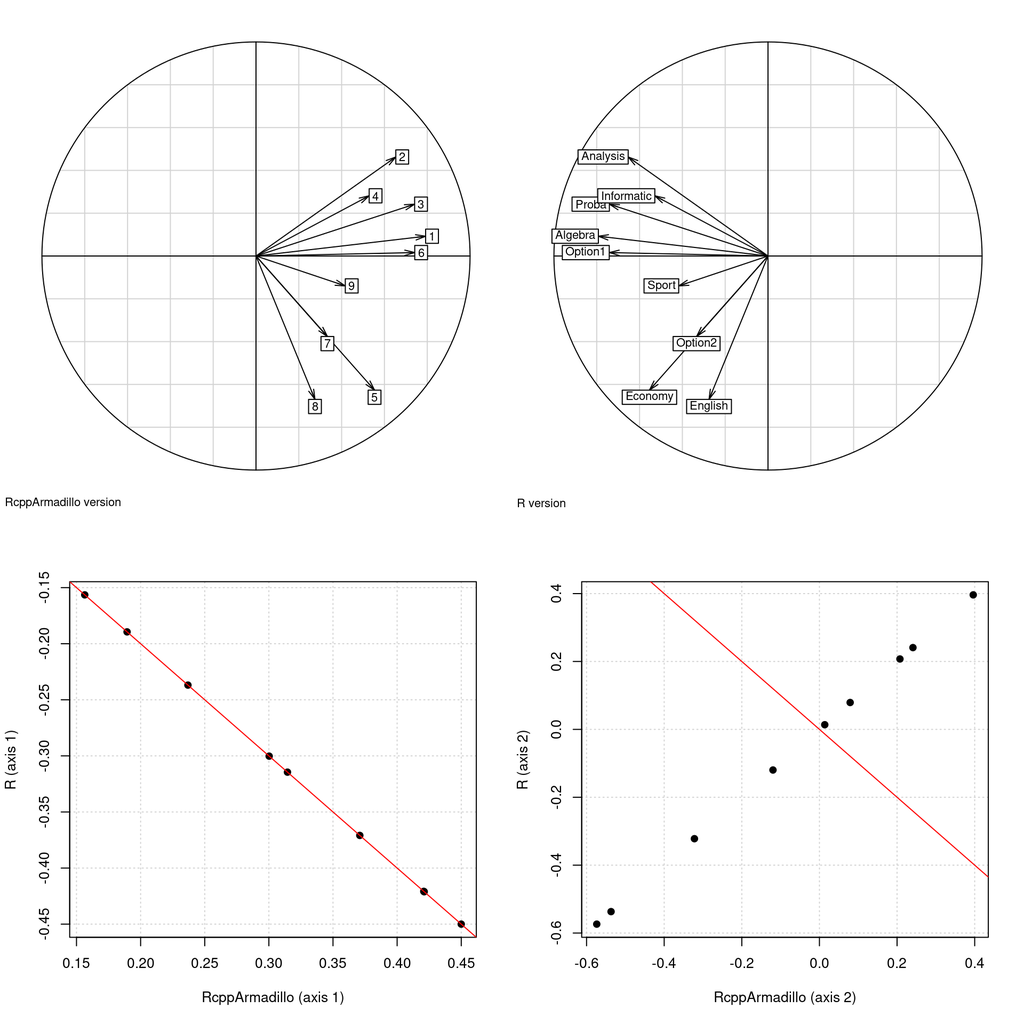

```r
par(mfrow=c(2,2))
s.corcircle(test2$co,sub="RcppArmadillo version")
s.corcircle(pca2$co,sub="R version")
plot(test2$c1[,1],pca2$c1[,1],panel.first=c(grid()),xlab="RcppArmadillo (axis 1)",ylab="R (axis 1)",pch=19);abline(0,-1,col="red")
plot(test2$c1[,2],pca2$c1[,2],panel.first=c(grid()),xlab="RcppArmadillo (axis 2)",ylab="R (axis 2)",pch=19);abline(0,-1,col="red")
```

## 7.4 Test COA

```r
sourceCpp(file.path(getwd(),"src","utility.cpp"))
data(rpjdl)
chisq.test(rpjdl$fau)$statistic
```

```
## X-squared
##  7323.597
```

```r
rpjdl.coa <- coa1 <- dudi.coa(rpjdl$fau, scannf = FALSE, nf = 4)
sum(rpjdl.coa$eig)*rpjdl.coa$N # the same
```

```
## [1] 7323.597
```

```r
test <- arc_coa(as.matrix(rpjdl$fau),nf=2)
```

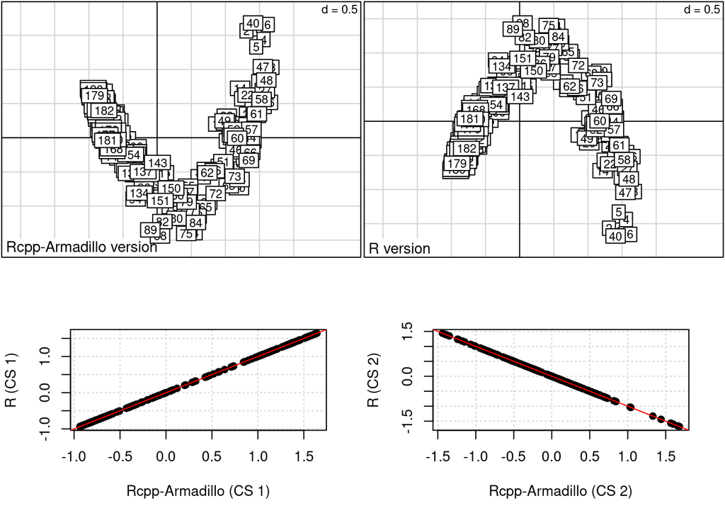

```r
coordli <- test$li
par(mfrow=c(2,2))
s.label(coordli,sub="Rcpp-Armadillo version")
s.label(coa1$li,sub="R version")
plot(coordli[,1],coa1$li[,1],panel.first=c(grid()),xlab="Rcpp-Armadillo (CS 1)",ylab="R (CS 1)",pch=19);abline(0,1,col="red")
plot(coordli[,2],coa1$li[,2],panel.first=c(grid()),xlab="Rcpp-Armadillo (CS 2)",ylab="R (CS 2)",pch=19);abline(0,-1,col="red")
```

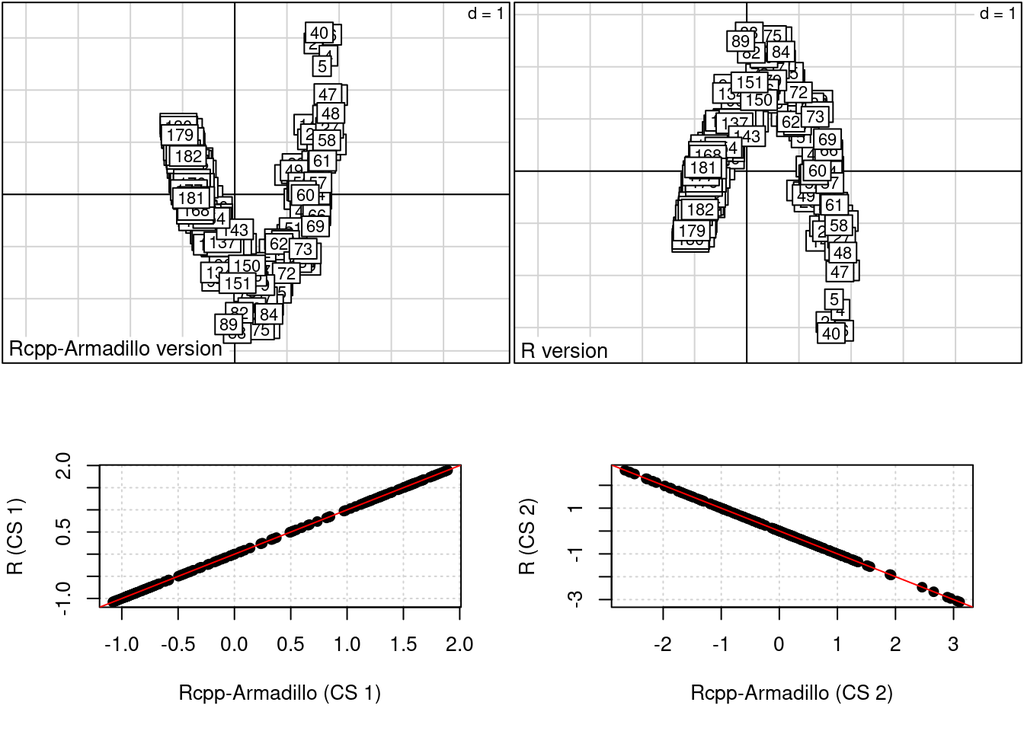

```r
coordl1 <- test$l1
par(mfrow=c(2,2))
s.label(coordl1,sub="Rcpp-Armadillo version")
s.label(coa1$l1,sub="R version")
plot(coordl1[,1],coa1$l1[,1],panel.first=c(grid()),xlab="Rcpp-Armadillo (CS 1)",ylab="R (CS 1)",pch=19);abline(0,1,col="red")
plot(coordl1[,2],coa1$l1[,2],panel.first=c(grid()),xlab="Rcpp-Armadillo (CS 2)",ylab="R (CS 2)",pch=19);abline(0,-1,col="red")
```

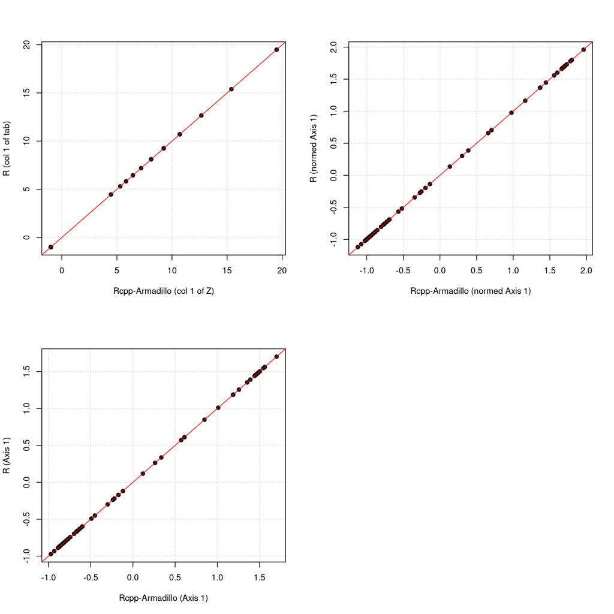

```r
par(mfrow=c(2,2))
plot(test$X[,1],coa1$tab[,1],panel.first=c(grid()),xlab="Rcpp-Armadillo (col 1 of Z)",ylab="R (col 1 of tab)",pch=19);abline(0,1,col="red")
plot(test$c1[,1],coa1$c1[,1],panel.first=c(grid()),xlab="Rcpp-Armadillo (normed Axis 1)",ylab="R (normed Axis 1)",pch=19);abline(0,1,col="red")
plot(test$co[,1],coa1$co[,1],panel.first=c(grid()),xlab="Rcpp-Armadillo (Axis 1)",ylab="R (Axis 1)",pch=19);abline(0,1,col="red")
```

## 7.5 Test MCA

```r
data(ours)
summary(ours)
```

```
##  altit  deniv  cloiso domain boise  hetra  favor  inexp  citat  depart
##  1: 8   1:13   1:12   1: 9   1:10   1:19   1:15   1:20   1:22   AHP:5
##  2:17   2:14   2: 4   2:13   2:15   2: 5   2:12   2:10   2: 7   AM :4
##  3:13   3:11   3:22   3:16   3:13   3:14   3:11   3: 8   3: 4   D  :5
##                                                          4: 5   HP :8
##                                                                 HS :4
##                                                                 I  :5
##                                                                 S  :7
```

```r
acm1 <- dudi.acm(ours, scan = FALSE)
```

for the first version of mca, we give the **disjonctif** table and the variable number.

```r
sourceCpp(file.path(getwd(),"src","utility.cpp"))
test <- arc_mca_proto(as.matrix(acm.disjonctif(ours)),lw=acm1$lw,v=ncol(ours),nf=2)
```

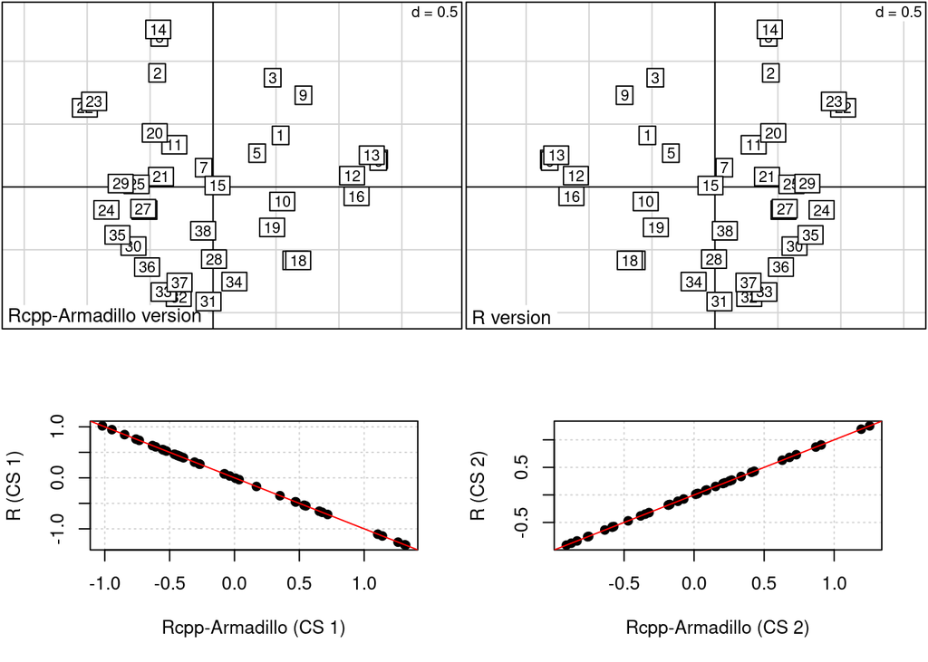

```r
coordli <- test$li
par(mfrow=c(2,2))
s.label(coordli,sub="Rcpp-Armadillo version")
s.label(acm1$li,sub="R version")
plot(coordli[,1],acm1$li[,1],panel.first=c(grid()),xlab="Rcpp-Armadillo (CS 1)",ylab="R (CS 1)",pch=19);abline(0,-1,col="red")
plot(coordli[,2],acm1$li[,2],panel.first=c(grid()),xlab="Rcpp-Armadillo (CS 2)",ylab="R (CS 2)",pch=19);abline(0,1,col="red")
```

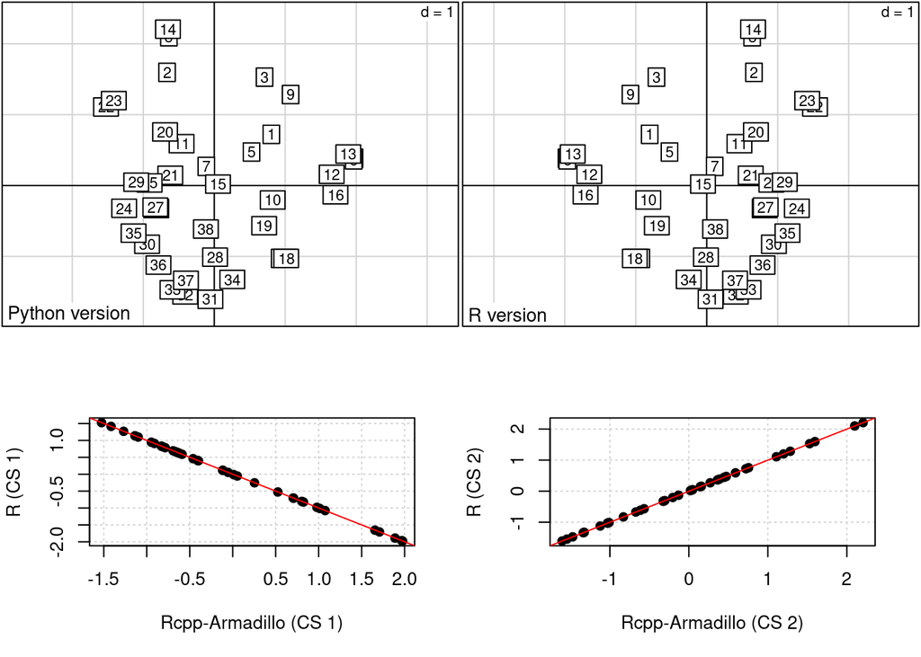

```r
coordl1 <- test$l1
par(mfrow=c(2,2))
s.label(coordl1,sub="Python version")
s.label(acm1$l1,sub="R version")
plot(coordl1[,1],acm1$l1[,1],panel.first=c(grid()),xlab="Rcpp-Armadillo (CS 1)",ylab="R (CS 1)",pch=19);abline(0,-1,col="red")
plot(coordl1[,2],acm1$l1[,2],panel.first=c(grid()),xlab="Rcpp-Armadillo (CS 2)",ylab="R (CS 2)",pch=19);abline(0,1,col="red")
```

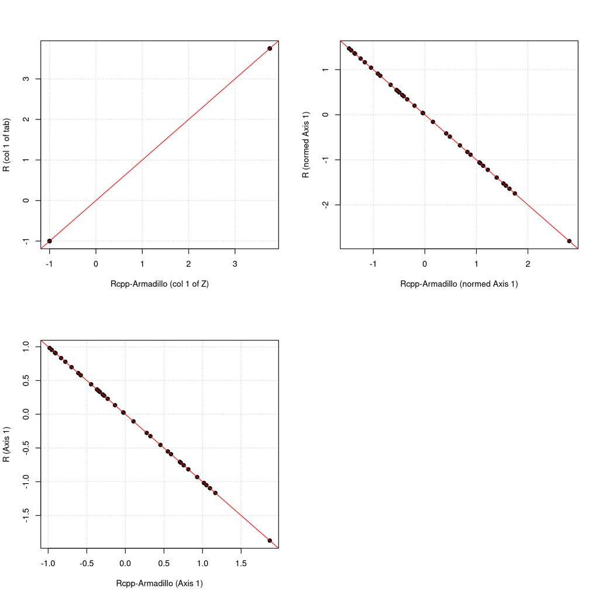

```r
par(mfrow=c(2,2))
plot(test$X[,1],acm1$tab[,1],panel.first=c(grid()),xlab="Rcpp-Armadillo (col 1 of Z)",ylab="R (col 1 of tab)",pch=19);abline(0,1,col="red")
plot(test$c1[,1],acm1$c1[,1],panel.first=c(grid()),xlab="Rcpp-Armadillo (normed Axis 1)",ylab="R (normed Axis 1)",pch=19);abline(0,-1,col="red")
plot(test$co[,1],acm1$co[,1],panel.first=c(grid()),xlab="Rcpp-Armadillo (Axis 1)",ylab="R (Axis 1)",pch=19);abline(0,-1,col="red")
```

encoding **disjonctif** table

```r
sourceCpp(file.path(getwd(),"src","utility.cpp"))
w <- factor(c("a","a","b","c"))
acm.util(w)
```

```
##      a b c
## [1,] 1 0 0
## [2,] 1 0 0
## [3,] 0 1 0
## [4,] 0 0 1
```

```r
arc_acmutil(w)
```

```
##      [,1] [,2] [,3]
## [1,]    1    0    0
## [2,]    1    0    0
## [3,]    0    1    0
## [4,]    0    0    1
```

```r
w1 <- factor(c("e","d","e","f"))
arc_disjonctif(cbind(w,w1))
```

```
##      [,1] [,2] [,3] [,4] [,5] [,6]
## [1,]    1    0    0    0    1    0
## [2,]    1    0    0    1    0    0
## [3,]    0    1    0    0    1    0
## [4,]    0    0    1    0    0    1
```

```r
test <- arc_mca( as.matrix(apply(ours,2,function(x) as.numeric(factor(x)))),lw=acm1$lw,nf=2)
```

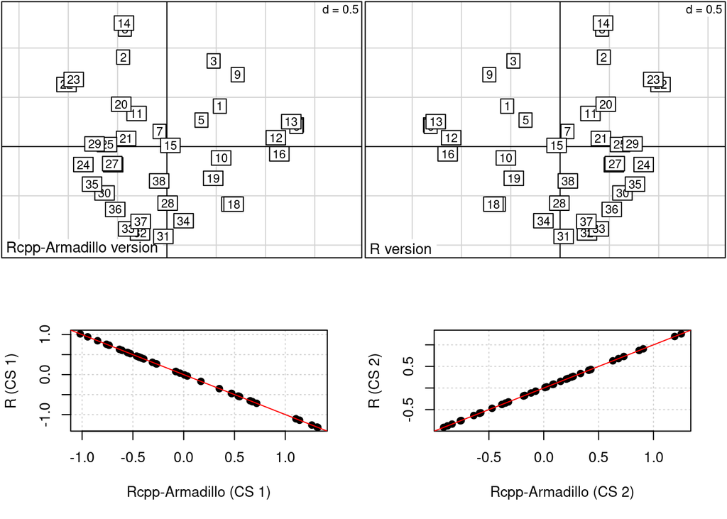

```r
coordli <- test$li
par(mfrow=c(2,2))
s.label(coordli,sub="Rcpp-Armadillo version")
s.label(acm1$li,sub="R version")
plot(coordli[,1],acm1$li[,1],panel.first=c(grid()),xlab="Rcpp-Armadillo (CS 1)",ylab="R (CS 1)",pch=19);abline(0,-1,col="red")
plot(coordli[,2],acm1$li[,2],panel.first=c(grid()),xlab="Rcpp-Armadillo (CS 2)",ylab="R (CS 2)",pch=19);abline(0,1,col="red")
```

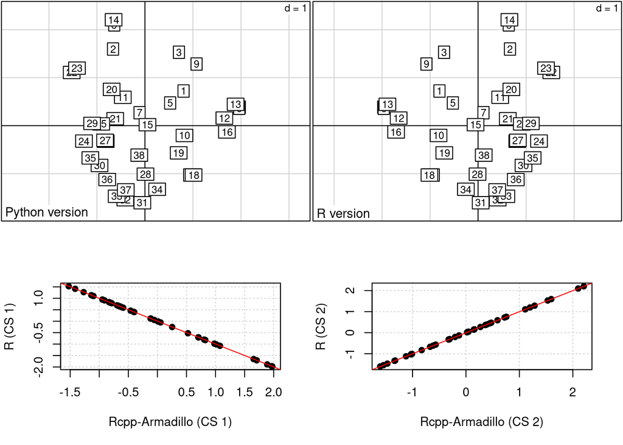

```r
coordl1 <- test$l1
par(mfrow=c(2,2))
s.label(coordl1,sub="Python version")
s.label(acm1$l1,sub="R version")
plot(coordl1[,1],acm1$l1[,1],panel.first=c(grid()),xlab="Rcpp-Armadillo (CS 1)",ylab="R (CS 1)",pch=19);abline(0,-1,col="red")
plot(coordl1[,2],acm1$l1[,2],panel.first=c(grid()),xlab="Rcpp-Armadillo (CS 2)",ylab="R (CS 2)",pch=19);abline(0,1,col="red")
```

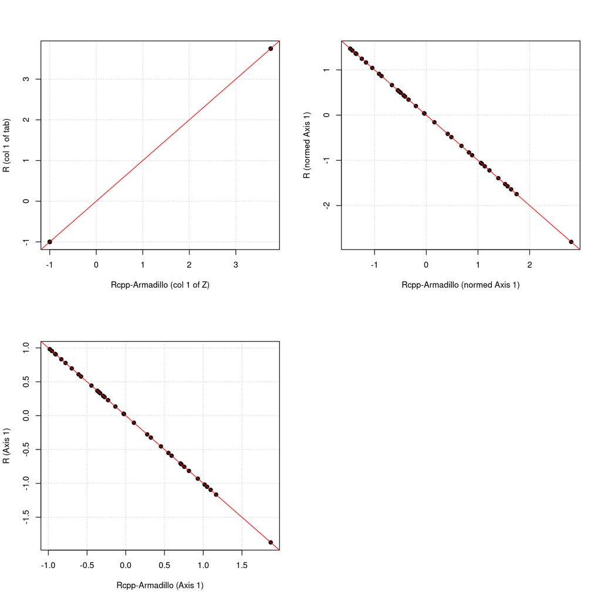

```r
par(mfrow=c(2,2))
plot(test$X[,1],acm1$tab[,1],panel.first=c(grid()),xlab="Rcpp-Armadillo (col 1 of Z)",ylab="R (col 1 of tab)",pch=19);abline(0,1,col="red")
plot(test$c1[,1],acm1$c1[,1],panel.first=c(grid()),xlab="Rcpp-Armadillo (normed Axis 1)",ylab="R (normed Axis 1)",pch=19);abline(0,-1,col="red")
plot(test$co[,1],acm1$co[,1],panel.first=c(grid()),xlab="Rcpp-Armadillo (Axis 1)",ylab="R (Axis 1)",pch=19);abline(0,-1,col="red")
```

# 8 Multifactorial analysis based on GPU computation with R

see https://jaredlander.com/content/2021/09/GPUComputingWithR.html#35

R packages **GPUmatrix** and **torch**

```r
library(GPUmatrix)
library(torch)
```

```r
library(ade4)

as.dudi.gpu <- function (df, col.w, row.w, scannf, nf, call, type, tol = 1e-07,
    full = FALSE){
    if (!is.data.frame(df))
        stop("data.frame expected")
    lig <- nrow(df)
    col <- ncol(df)
    if (length(col.w) != col)
        stop("Non convenient col weights")
    if (length(row.w) != lig)
        stop("Non convenient row weights")
    if (any(col.w < 0))
        stop("col weight < 0")
    if (any(row.w < 0))
        stop("row weight < 0")
    if (full)
        scannf <- FALSE
    transpose <- FALSE
    if (lig < col)
        transpose <- TRUE
    res <- list(tab = df, cw = col.w, lw = row.w)
    df <- as.matrix(df)
    df.ori <- df
    df <- df * sqrt(row.w)
    df <- sweep(df, 2, sqrt(col.w), "*")
#### conversion matrix into gpu.matrix
    df <- as.gpu.matrix(df)
    if (!transpose) {
        df <- crossprod(df, df)
    }
    else {
        df <- tcrossprod(df, df)
    }
    eig0 <- eigen(df, symmetric = TRUE)
    eig1 <- list(values = as.vector(Re(eig0$values)),
                vectors=as.matrix(Re(eig0$vectors)))
    eig <- eig1$values
    rank <- sum((eig/eig[1]) > tol)
### end of GPU computation
    if (scannf) {
        if (exists("ade4TkGUIFlag")) {
            nf <- ade4TkGUI::chooseaxes(eig, rank)
        }
        else {
            barplot(eig[1:rank])
            cat("Select the number of axes: ")
            nf <- as.integer(readLines(n = 1))
            messageScannf(call, nf)
        }
    }
    if (nf <= 0)
        nf <- 2
    if (nf > rank)
        nf <- rank
    if (full)
        nf <- rank
    res$eig <- eig[1:rank]
    res$rank <- rank
    res$nf <- nf
    col.w[which(col.w == 0)] <- 1
    row.w[which(row.w == 0)] <- 1
    dval <- sqrt(res$eig)[1:nf]
    if (!transpose) {
        col.w <- 1/sqrt(col.w)
        auxi <- eig1$vectors[, 1:nf] * col.w
        auxi2 <- sweep(df.ori, 2, res$cw, "*")
        auxi2 <- data.frame(auxi2 %*% auxi)
        auxi <- data.frame(auxi)
        names(auxi) <- paste("CS", (1:nf), sep = "")
        row.names(auxi) <- make.unique(names(res$tab))
        res$c1 <- auxi
        names(auxi2) <- paste("Axis", (1:nf), sep = "")
        row.names(auxi2) <- row.names(res$tab)
        res$li <- auxi2
        res$co <- sweep(res$c1, 2, dval, "*")
        names(res$co) <- paste("Comp", (1:nf), sep = "")
        res$l1 <- sweep(res$li, 2, dval, "/")
        names(res$l1) <- paste("RS", (1:nf), sep = "")
    }
    else {
        row.w <- 1/sqrt(row.w)
        auxi <- eig1$vectors[, 1:nf] * row.w
        auxi2 <- t(sweep(df.ori, 1, res$lw, "*"))
        auxi2 <- data.frame(auxi2 %*% auxi)
        auxi <- data.frame(auxi)
        names(auxi) <- paste("RS", (1:nf), sep = "")
        row.names(auxi) <- row.names(res$tab)
        res$l1 <- auxi
        names(auxi2) <- paste("Comp", (1:nf), sep = "")
        row.names(auxi2) <- make.unique(names(res$tab))
        res$co <- auxi2
        res$li <- sweep(res$l1, 2, dval, "*")
        names(res$li) <- paste("Axis", (1:nf), sep = "")
        res$c1 <- sweep(res$co, 2, dval, "/")
        names(res$c1) <- paste("CS", (1:nf), sep = "")
    }
    res$call <- call
    class(res) <- c(type, "dudi")
    return(res)
}

dudi.pca.gpu <- function (df, row.w = rep(1, nrow(df))/nrow(df), col.w = rep(1,
    ncol(df)), center = TRUE, scale = TRUE, scannf = TRUE, nf = 2){
    df <- as.data.frame(df)
    nc <- ncol(df)
    if (any(is.na(df)))
        stop("na entries in table")
    f1 <- function(v) sum(v * row.w)/sum(row.w)
    f2 <- function(v) sqrt(sum(v * v * row.w)/sum(row.w))
    if (is.logical(center)) {
        if (center) {
            center <- apply(df, 2, f1)
            df <- sweep(df, 2, center)
        }
        else center <- rep(0, nc)
    }
    else if (is.numeric(center) && (length(center) == nc))
        df <- sweep(df, 2, center)
    else stop("Non convenient selection for center")
    if (scale) {
        norm <- apply(df, 2, f2)
        norm[norm < 1e-08] <- 1
        df <- sweep(df, 2, norm, "/")
    }
    else norm <- rep(1, nc)
    X <- as.dudi.gpu(df, col.w, row.w, scannf = scannf, nf = nf,
        call = match.call(), type = "pca")
    X$cent <- center
    X$norm <- norm
    X
}


#### test
data(deug)
dudi1 <- dudi.pca(deug$tab, center = TRUE, scale = TRUE, scan = FALSE)
dudi2 <- dudi.pca.gpu(deug$tab, center = TRUE, scale = TRUE, scan = FALSE)
```

test with linear algebric functions from the R package **torch**:

```r
library(torch)
apropos("linalg")
#  [1] "linalg_cholesky"            "linalg_cholesky_ex"         "linalg_cond"                "linalg_det"
#  [5] "linalg_eig"                 "linalg_eigh"                "linalg_eigvals"             "linalg_eigvalsh"
#  [9] "linalg_householder_product" "linalg_inv"                 "linalg_inv_ex"              "linalg_lstsq"
# [13] "linalg_matrix_norm"         "linalg_matrix_power"        "linalg_matrix_rank"         "linalg_multi_dot"
# [17] "linalg_norm"                "linalg_pinv"                "linalg_qr"                  "linalg_slogdet"
# [21] "linalg_solve"               "linalg_svd"                 "linalg_svdvals"             "linalg_tensorinv"
# [25] "linalg_tensorsolve"         "linalg_vector_norm"
```

# 9 Multifactorial analysis based on GPU computation with Python

In this section, the library **cupy** (https://cupy.dev/) is used to implement the duality diagram.

```python
import os
import string
import re
import pandas as pd
import numpy as np
import cupy as cu

def cupydudi(X,cw,lw,nf):
  dim = X.shape
  n = dim[0]
  p = dim[1]
  nf0 = nf-1
  # n=len(X)
  # p=len(X.columns)
  D = cu.diag(cu.sqrt(lw))
  Q = cu.diag(cu.sqrt(cw))

  # XtDXQ => problem  with Q !!!

  XD = cu.dot(X.T,D).T
  XD = cu.dot(XD,Q)
  XtX = cu.dot(XD.T,XD)


  # decomposition
  eigenvalues, eigenvectors = cu.linalg.eig(XtX)
  index = cu.argsort(eigenvalues)[::-1]

  # np.nonzero(eigenvalues)[0]
  eigenvalues = eigenvalues.real
  eigenvectors = eigenvectors.real
  eigenvalues=eigenvalues[index]
  eigenvectors=eigenvectors[:,index]
  # results
  rank = len(cu.nonzero(eigenvalues)[0])
  C1 = cu.dot(cu.diag(1/cu.sqrt(cw)),eigenvectors[:,0:nf])
  #C1 = eigenvectors[:,0:nf]
  XQ = cu.dot(X,cu.diag(cw))
  Li = cu.dot(XQ, C1)

  # need to adjust the weighting (problem with sqrt)
  L1 = cu.dot(Li,cu.diag(1/cu.sqrt(eigenvalues[0:nf])))
  Co = cu.dot(C1,cu.diag(cu.sqrt(eigenvalues[0:nf])))
  return eigenvalues,rank,Li,L1,Co,C1,nf;

###
```

# 10 Future development for the Package pydudi

modification of the names used for the function (?)

- check names and use of the function
- add acmutil function for the preparation of the Burt’s table

implementation in python:

- class Ktab
- function coinertia
- function pls
- function spls
- function gpls
- function mbpls
- function smbpls
- function statis
- function mfa
- function mcoa
- function gpa
- function coinertia

NOTA: The objective of this works is not to replace the R package ade4, but it’s just a manner to improve my skill in python.

# 11 References

Back to top

- R http://www.R-project.org/.
- R Core Team (2013). R: A language and environment for statistical computing. R Foundation for Statistical Computing, Vienna, Austria. URL http://www.R-project.org/.
- Dray S, Dufour A (2007). “The ade4 Package: Implementing the Duality Diagram for Ecologists.” *Journal of Statistical Software*, *22*(4), 1-20. doi:10.18637/jss.v022.i04 https://doi.org/10.18637/jss.v022.i04.
- Chessel D, Dufour A, Thioulouse J (2004). “The ade4 Package - I: One-Table Methods.” *R News*, *4*(1), 5-10. https://cran.r-project.org/doc/Rnews/.
- Dray S, Dufour A, Chessel D (2007). “The ade4 Package - II: Two-Table and K-Table Methods.” *R News*, *7*(2), 47-52. https://cran.r-project.org/doc/Rnews/.
- Thioulouse J, Dray S, Dufour A, Siberchicot A, Jombart T, Pavoine S (2018). *Multivariate Analysis of Ecological Data with ade4*. Springer. doi:10.1007/978-1-4939-8850-1 https://doi.org/10.1007/978-1-4939-8850-1.
- Escoufier, Y. (1987) The duality diagram : a means of better practical applications In Development in numerical ecology, Legendre, P. & Legendre, L. (Eds.) NATO advanced Institute, Serie G. Springer Verlag, Berlin, 139–156.
- Benzécri, J.P. and Coll. (1973) *L’analyse des données. II L’analyse des correspondances*, Bordas, Paris. 1-620.
- Greenacre, M. J. (1984) *Theory and applications of correspondence analysis*, Academic Press, London.
- Tenenhaus, M. & Young, F.W. (1985) An analysis and synthesis of multiple correspondence analysis, optimal scaling, dual scaling, homogeneity analysis ans other methods for quantifying categorical multivariate data. Psychometrika, 50, 1, 91-119.
- Lebart, L., A. Morineau, and M. Piron. 1995. Statistique exploratoire multidimensionnelle. Dunod, Paris.

# 12 Appendix

Back to top